# Simulation Studies Based on ACTG175: Survival Endpoint (Benefit Search)

- Show All Code
- Hide All Code
- View Source

Adapting the ForestSearch Framework to Identify Treatment Benefit in HIV Clinical Trial Data

Author

Larry F. Leon

Published

April 25, 2026

# 1 Introduction

## 1.1 Motivation

Leon et al. (2024) demonstrated the ForestSearch methodology using the German Breast Cancer Study Group (GBSG) dataset (`survival::gbsg`) as both the applied analysis target and the covariate template for simulation studies. The `setup_gbsg_dgm()` convenience function encodes all GBSG-specific preparation choices — variable discretisation, subgroup definition, Weibull calibration — into a single reproducible call.

This document adapts the same simulation framework to the **AIDS Clinical Trials Group Study 175** (ACTG175) dataset from the `speff2trial` package. ACTG175 is a randomised trial of four antiretroviral regimens in HIV-infected subjects (Hammer et al., *NEJM* 1996). Following León et al. (2024, Section 4.2), we compare **arm 1** (zidovudine + didanosine, ZDV+ddI) to **arm 3** (didanosine alone, ddI) and search for a subgroup with **pronounced treatment benefit** ($N = 1{,}083$).

The adaptation serves two purposes:

1. **Methodological validation**: confirming that the ForestSearch operating characteristics generalise beyond the GBSG breast cancer setting to a different disease, population, endpoint structure, and covariate set — and specifically to the **benefit-search** variant of the algorithm.
2. **Template for new-dataset simulations**: demonstrating the recommended workflow when `setup_gbsg_dgm()` is not appropriate and the analyst must use `generate_aft_dgm_flex()` directly.

## 1.2 Benefit Search via Treatment Switching

ForestSearch’s default mode identifies subgroups where treatment is **detrimental** (hazard ratio $> 1$). To identify subgroups with **pronounced benefit** instead, León et al. (2024, §4.2) introduced a treatment-switching approach:

1. **Switch treatment roles**: recode the treatment indicator so that control becomes “treatment” and vice versa. In the ACTG175 context: ddI monotherapy (originally control) is recoded as `treat = 1`, and ZDV+ddI combination (originally experimental) becomes `treat = 0`.
2. **Raise the thresholds**: under switched roles, a subgroup that strongly benefits from the original treatment will appear to have a high HR (ddI alone is worse for these patients). The paper used:
   - $c_1 = 1/0.60 \approx 1.667$ (screening: original HR $\leq 0.60$)
   - $c_2 = 1/0.80 = 1.25$ (consistency: original HR $\leq 0.80$)
3. **Run ForestSearch** with these thresholds on the switched data. The identified “harm” subgroup $\hat{H}$ under switched roles is the **benefit** subgroup $\hat{Q}$ under the original treatment coding.
4. **Invert the results**: hazard ratios reported by ForestSearch are inverted ($1/\text{HR}$) to return to the original treatment scale.

In the paper’s analysis, this approach identified $\hat{Q} = \{\text{Age} > 34 \cap \text{Preanti} \leq 744.5\}$ with a bias-corrected HR of $0.59$ ($0.37$, $0.94$) — a substantially stronger benefit than the ITT HR of $0.84$.

The simulation DGM in this document is built on the **switched** treatment data. All ForestSearch analyses run on the switched indicator. The calibration target HR $= 2.0$ (under switched treatment) corresponds to an original-scale HR $= 0.50$, representing a strong treatment benefit in the subgroup.

## 1.3 Adaptation Checklist

To substitute your own trial data for ACTG175, you must address each of the following steps. The sections that follow implement each one for ACTG175; cross-references are provided so you can see the concrete implementation alongside each checklist item.

| Step | What to do | Section |
| --- | --- | --- |
| **1. Load your data** | Create `id`, `y` (observed time), `event` (0/1 indicator), and `treat` (0 = control, 1 = treatment) columns. Time units for `y` set the time scale for the entire simulation. | Section 2 |
| **2. Choose confounders** | Identify the candidate variables for the subgroup search. These become `factor_vars` in the DGM and `confounders_base` in the simulation. | Section 2 |
| **3. Discretise continuous variables** | Create binary `z1`, `z2`, … columns from continuous covariates. Document your cutpoint rationale (see Section 1.4). | Section 2 |
| **4. Define the harm subgroup** | Set `dgm_subgroup_vars` and `dgm_subgroup_cuts` consistently with your factor coding. Verify with an explicit `stopifnot()` check. | Section 4 |
| **5. Set time-scale parameters** | Ensure `sim_analysis_time` is in the same units as your outcome variable. Run the time-scale diagnostic after DGM creation. | Section 4 |
| **6. Update `cox_formula_adj`** | Include confounders appropriate for your study. The formula must use simulated column names (`y_sim`, `event_sim`, `treat_sim`). | Setup chunk |
| **7. Update `confounders_base`** | This must list all `z*` variable names passed to ForestSearch and GRF. It must match `factor_vars` in the DGM call. | Section 6 |
| **8. Calibrate `k_inter`** | Run the grid search targeting a clinically meaningful HR(H). | Section 4.3 |
| **9. Run time-scale diagnostic** | Verify `exp(dgm$model_params$mu)` is close to your observed median event time. | Section 4.2.1 |
| **10. Run censoring diagnostic** | Use `check_censoring_dgm()` to compare simulated vs observed censoring. | Section 5.1 |
| **11. Set simulation count** | Use $\geq 500$ replicates for stable operating characteristics. | Section 6 |

## 1.4 Choosing Discretisation Cutpoints

For your own dataset, we recommend starting with strategy (1) where available, falling back to (2), and optionally using (3) as a sensitivity analysis. Whichever approach you choose, document the rationale alongside the cutpoint value in your setup chunk.

## 1.5 Steps for Swapping GBSG with ACTG175

Replacing the GBSG template with ACTG175 requires changes at every stage of the simulation pipeline. The table below summarises each change; subsequent sections implement them in detail.

[output not shown]

The benefit subgroup definition for ACTG175 is derived from the ForestSearch analysis in León et al. (2024, Section 4.2), which identified Age $> 34$ and prior antiretroviral therapy $\leq 744.5$ days as the combination defining a subgroup with pronounced treatment benefit ($\hat{Q}$: HR $= 0.59$, $0.37$–$0.94$).

# 2 Side-by-Side Dataset Comparison

```r
library(forestsearch)
library(survival)
library(speff2trial)
library(data.table)
library(ggplot2)
library(patchwork)
library(gt)
library(foreach)
library(doFuture)
library(future)

# -- Safe foreach result collection -------------------------------------------
# collect_results() now lives in forestsearch (R/forestsearch_helpers.R).
# Called via ::: since it is an internal (unexported) utility.
```

## 2.1 Loading and Preparing Both Datasets

The code below prepares both datasets for the simulation framework. For each dataset, the key steps are:

1. Create a standardised outcome variable (`y`) in the dataset’s natural time units.
2. Create a binary treatment indicator (`treat`: 0 = control, 1 = treatment).
3. Discretise continuous covariates into binary factors (`z1`, `z2`, …) using the cutpoints defined in the setup chunk.
4. Construct the true harm-subgroup indicator (`flag_harm`) using the same variables and levels specified in `dgm_subgroup_vars` and `dgm_subgroup_cuts`.

```r
# ── GBSG ──────────────────────────────────────────────────────
gbsg_df        <- survival::gbsg
gbsg_df$y      <- gbsg_df$rfstime / 30.4375
gbsg_df$treat  <- gbsg_df$hormon

er_cut         <- quantile(gbsg_df$er, probs = gbsg_er_quantile)
gbsg_df$z1     <- as.factor(ifelse(gbsg_df$er <= er_cut, 1L, 0L))
gbsg_df$z3     <- as.factor(ifelse(gbsg_df$meno == 0, 1L, 0L))
gbsg_df$flag_harm <- as.integer(gbsg_df$z1 == 1 & gbsg_df$z3 == 1)

# ── ACTG175 ───────────────────────────────────────────────────
# Select arms 1 (ZDV+ddI) and 3 (ddI alone), matching the paper
actg_df        <- subset(speff2trial::ACTG175, arms %in% actg_arms)
actg_df$id     <- seq_len(nrow(actg_df))
actg_df$time_days   <- actg_df$days
actg_df$time_months <- actg_df$time_days / 30.4375

# Original treatment coding: arm 1 (ZDV+ddI) = 1, arm 3 (ddI) = 0
actg_df$treat_orig <- ifelse(actg_df$arms == actg_treat_arm, 1L, 0L)

# SWITCHED treatment coding for benefit search:
# ddI (arm 3) = 1 ("treatment"), ZDV+ddI (arm 1) = 0 ("control")
# Under switched roles, ForestSearch's harm-detection machinery
# identifies the BENEFIT subgroup Q.
actg_df$treat  <- 1L - actg_df$treat_orig

cat(sprintf("ACTG175: N = %d (arm 1: n=%d, arm 3: n=%d)\n",
    nrow(actg_df),
    sum(actg_df$treat_orig == 1), sum(actg_df$treat_orig == 0)))
```

```
#> ACTG175: N = 1083 (arm 1: n=522, arm 3: n=561)
```

```r
cat(sprintf("Treatment switched: treat=1 is ddI (original control)\n"))
```

```
#> Treatment switched: treat=1 is ddI (original control)
```

```r
# ── Discretise continuous variables into binary factors ───────
# Subgroup-defining variables (from Leon et al. 2024, Section 4.2):
# z1: age > actg_age_cut  (subgroup factor 1 — older patients)
actg_df$z1  <- as.factor(ifelse(actg_df$age  > actg_age_cut,  1L, 0L))
# z2: preanti <= actg_preanti_cut  (subgroup factor 2 — less prior treatment)
actg_df$z2  <- as.factor(ifelse(actg_df$preanti <= actg_preanti_cut, 1L, 0L))
# z3: weight <= actg_wtkg_cut (prognostic)
actg_df$z3  <- as.factor(ifelse(actg_df$wtkg <= actg_wtkg_cut, 1L, 0L))
# z4: Karnofsky <= median (data-driven cutpoint)
actg_df$z4  <- as.factor(ifelse(
  actg_df$karnof <= median(actg_df$karnof), 1L, 0L
))
# z5: CD4 baseline <= median (data-driven cutpoint)
actg_df$z5  <- as.factor(ifelse(
  actg_df$cd40 <= median(actg_df$cd40), 1L, 0L
))
# z6: CD8 <= median (data-driven cutpoint)
actg_df$z6  <- as.factor(ifelse(
  actg_df$cd80 <= median(actg_df$cd80), 1L, 0L
))
# z7-z12: binary indicators (passed through as-is from the dataset)
actg_df$z7  <- as.factor(actg_df$hemo)
actg_df$z8  <- as.factor(actg_df$homo)
actg_df$z9  <- as.factor(actg_df$drugs)
actg_df$z10 <- as.factor(actg_df$race)
actg_df$z11 <- as.factor(actg_df$gender)
actg_df$z12 <- as.factor(actg_df$symptom)

# ── Realistic analyst-facing candidate set ──────────────────────
# The truly-binary indicators are coerced to factors so forestsearch's
# is.continuous() detection treats them as categorical (no median /
# GRF cut attempted).  The continuous columns (age, preanti, wtkg,
# karnof, cd40, cd80) are left in their RAW numeric form -- the
# search methods discover cuts.  The z1-z12 factors built above
# remain on the data frame only for the DGM (factor_vars argument)
# and the truth flag.
for (v in analysis_binary_vars) {
  actg_df[[v]] <- as.factor(actg_df[[v]])
}
confounders_analysis <- c(analysis_continuous_vars, analysis_binary_vars)

# ── Factor coding summary ──────────────────────────────────────
# z1  = 1 => age > 34          (older — benefit subgroup factor)
# z2  = 1 => preanti <= 744.5  (less prior ART — benefit subgroup factor)
# z3  = 1 => weight <= 75 kg   (low weight)
# z4  = 1 => Karnofsky <= median (lower performance)
# z5  = 1 => CD4 <= median     (lower baseline CD4)
# z6  = 1 => CD8 <= median     (lower CD8)
# z7  = 1 => hemophilia yes
# z8  = 1 => homosexual activity yes
# z9  = 1 => IV drug use yes
# z10 = 1 => non-white
# z11 = 1 => male
# z12 = 1 => symptomatic yes

# ── Benefit subgroup: z1 = 1 AND z2 = 1 ───────────────────────
# Q = {Age > 34 AND Preanti <= 744.5}
# Under switched treatment, Q appears as the "harm" subgroup.
actg_df$flag_harm <- as.integer(
  actg_df[[dgm_subgroup_vars[1]]] == dgm_subgroup_cuts[[dgm_subgroup_vars[1]]] &
  actg_df[[dgm_subgroup_vars[2]]] == dgm_subgroup_cuts[[dgm_subgroup_vars[2]]]
)

# Verify subgroup definition matches expectations
stopifnot(
  identical(dgm_subgroup_vars, c("z1", "z2")),
  identical(dgm_subgroup_cuts, list(z1 = 1L, z2 = 1L))
)
cat(sprintf(
  "Benefit subgroup Q: z1 == 1 (age > %d) AND z2 == 1 (preanti <= %.1f)\n",
  actg_age_cut, actg_preanti_cut
))
```

```
#> Benefit subgroup Q: z1 == 1 (age > 34) AND z2 == 1 (preanti <= 744.5)
```

```r
cat(sprintf(
  "  Q prevalence: %d / %d (%.1f%%)\n",
  sum(actg_df$flag_harm), nrow(actg_df),
  100 * mean(actg_df$flag_harm)
))
```

```
#>   Q prevalence: 382 / 1083 (35.3%)
```

## 2.2 Structural Comparison

```r
comp <- data.frame(
  Feature = c(
    "Disease area",
    "Trial name",
    "R package",
    "Total N (used)",
    "Treatment arms",
    "Outcome",
    "Time unit",
    "Median follow-up",
    "Event rate",
    "Treatment effect (ITT HR)",
    "Subgroup definition (H)",
    "H prevalence",
    "N confounders (binary)",
    "Confounder types"
  ),
  GBSG = c(
    "Breast cancer",
    "German Breast Cancer Study Group",
    "survival::gbsg",
    sprintf("%d", nrow(gbsg_df)),
    "Hormonal therapy vs. control",
    "Recurrence-free survival",
    "Months",
    sprintf("%.1f months", median(gbsg_df$y)),
    sprintf("%.0f%%", 100 * mean(gbsg_df$status)),
    sprintf("%.3f", exp(coef(coxph(
      Surv(y, status) ~ treat, data = gbsg_df
    )))),
    sprintf("ER-low (Q%d) AND premenopausal",
            as.integer(gbsg_er_quantile * 100)),
    sprintf("%.0f%%", 100 * mean(gbsg_df$flag_harm)),
    "7",
    "All pre-discretised from continuous/categorical"
  ),
  ACTG175 = c(
    "HIV / AIDS",
    "AIDS Clinical Trials Group Study 175",
    "speff2trial::ACTG175",
    sprintf("%d", nrow(actg_df)),
    "ZDV+ddI (combination) vs. ddI (monotherapy)",
    "Time to >= 50% CD4 decline, AIDS, or death",
    "Months",
    sprintf("%.1f months", median(actg_df$time_months)),
    sprintf("%.0f%%", 100 * mean(actg_df$cens)),
    sprintf("%.3f", exp(coef(coxph(
      Surv(time_months, cens) ~ treat_orig, data = actg_df
    )))),
    sprintf("Age > %d AND Preanti <= %.0f", actg_age_cut, actg_preanti_cut),
    sprintf("%.0f%%", 100 * mean(actg_df$flag_harm)),
    "12",
    "Mix of binary indicators and discretised continuous"
  ),
  check.names = FALSE,
  stringsAsFactors = FALSE
)

gt::gt(comp) |>
  gt::tab_header(
    title = "Dataset Comparison: GBSG vs ACTG175"
  ) |>
  gt::cols_label(Feature = "") |>
  gt::tab_style(
    style = gt::cell_text(weight = "bold"),
    locations = gt::cells_body(columns = Feature)
  ) |>
  gt::tab_style(
    style = gt::cell_fill(color = "#F5F5F5"),
    locations = gt::cells_body(rows = seq(1, nrow(comp), by = 2))
  )
```

Side-by-side comparison of GBSG and ACTG175 datasets

Dataset Comparison: GBSG vs ACTG175

|  | GBSG | ACTG175 |
| --- | --- | --- |
| Disease area | Breast cancer | HIV / AIDS |
| Trial name | German Breast Cancer Study Group | AIDS Clinical Trials Group Study 175 |
| R package | survival::gbsg | speff2trial::ACTG175 |
| Total N (used) | 686 | 1083 |
| Treatment arms | Hormonal therapy vs. control | ZDV+ddI (combination) vs. ddI (monotherapy) |
| Outcome | Recurrence-free survival | Time to >= 50% CD4 decline, AIDS, or death |
| Time unit | Months | Months |
| Median follow-up | 35.6 months | 33.1 months |
| Event rate | 44% | 21% |
| Treatment effect (ITT HR) | 0.695 | 0.839 |
| Subgroup definition (H) | ER-low (Q25) AND premenopausal | Age > 34 AND Preanti <= 744 |
| H prevalence | 12% | 35% |
| N confounders (binary) | 7 | 12 |
| Confounder types | All pre-discretised from continuous/categorical | Mix of binary indicators and discretised continuous |

## 2.3 Confounder Mapping

```r
conf_map <- data.frame(
  Role = c(
    "Subgroup factor 1",
    "Subgroup factor 2",
    "Prognostic 1",
    "Prognostic 2",
    "Prognostic 3",
    "Prognostic 4",
    "Prognostic 5",
    "Demographic 1",
    "Demographic 2",
    "Demographic 3",
    "Demographic 4",
    "Demographic 5"
  ),
  `GBSG variable` = c(
    sprintf("z1: ER <= Q%d", as.integer(gbsg_er_quantile * 100)),
    "z3: premenopausal",
    "z2: age <= median",
    "z4: PgR <= median",
    "z5: nodes <= median",
    "v6: tumour size <= median",
    "v7: grade = 3",
    rep("---", 5)
  ),
  `ACTG175 variable` = c(
    sprintf("z1: age > %d", actg_age_cut),
    sprintf("z2: preanti <= %.0f days", actg_preanti_cut),
    sprintf("z3: weight <= %d kg", actg_wtkg_cut),
    "z4: Karnofsky <= median",
    "z5: CD4 baseline <= median",
    "z6: CD8 <= median",
    "z7: hemophilia",
    "z8: homosexual activity",
    "z9: IV drug use",
    "z10: race (non-white)",
    "z11: gender (male)",
    "z12: symptomatic"
  ),
  check.names = FALSE,
  stringsAsFactors = FALSE
)

gt::gt(conf_map) |>
  gt::tab_header(
    title = "Confounder Variable Mapping"
  ) |>
  gt::tab_style(
    style = gt::cell_fill(color = "#E3F2FD"),
    locations = gt::cells_body(rows = 1:2)
  ) |>
  gt::tab_source_note(
    "Highlighted rows define the harm subgroup H."
  )
```

Mapping of confounder variables between datasets

Confounder Variable Mapping

| Role | GBSG variable | ACTG175 variable |
| --- | --- | --- |
| Subgroup factor 1 | z1: ER <= Q25 | z1: age > 34 |
| Subgroup factor 2 | z3: premenopausal | z2: preanti <= 744 days |
| Prognostic 1 | z2: age <= median | z3: weight <= 75 kg |
| Prognostic 2 | z4: PgR <= median | z4: Karnofsky <= median |
| Prognostic 3 | z5: nodes <= median | z5: CD4 baseline <= median |
| Prognostic 4 | v6: tumour size <= median | z6: CD8 <= median |
| Prognostic 5 | v7: grade = 3 | z7: hemophilia |
| Demographic 1 | --- | z8: homosexual activity |
| Demographic 2 | --- | z9: IV drug use |
| Demographic 3 | --- | z10: race (non-white) |
| Demographic 4 | --- | z11: gender (male) |
| Demographic 5 | --- | z12: symptomatic |

Highlighted rows define the harm subgroup H.

## 2.4 Survival Curves (Observed Data)

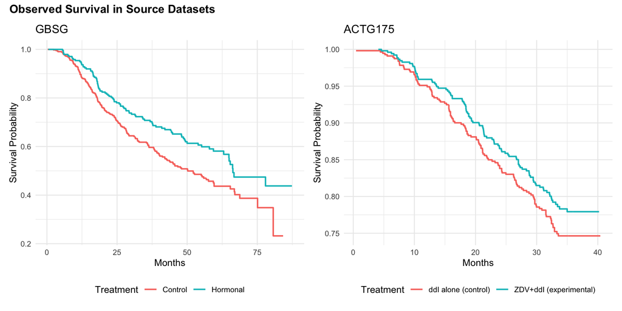

Kaplan-Meier curves in the observed datasets. Left: GBSG (hormonal therapy). Right: ACTG175 (ZDV+ddI vs ddI, original treatment coding).

```r
# ── GBSG KM ──────────────────────────────────────────────────
km_gbsg    <- survfit(Surv(y, status) ~ treat, data = gbsg_df)
km_gbsg_df <- data.frame(
  time = c(km_gbsg$time[1:km_gbsg$strata[1]],
           km_gbsg$time[(km_gbsg$strata[1] + 1):sum(km_gbsg$strata)]),
  surv = c(km_gbsg$surv[1:km_gbsg$strata[1]],
           km_gbsg$surv[(km_gbsg$strata[1] + 1):sum(km_gbsg$strata)]),
  arm = c(
    rep("Control", km_gbsg$strata[1]),
    rep("Hormonal", km_gbsg$strata[2])
  )
)

p_gbsg <- ggplot(km_gbsg_df, aes(x = time, y = surv, colour = arm)) +
  geom_step(linewidth = 0.8) +
  labs(
    title = "GBSG",
    x = "Months", y = "Survival Probability",
    colour = "Treatment"
  ) +
  theme_minimal(base_size = 11) +
  theme(legend.position = "bottom")

# ── ACTG175 KM ───────────────────────────────────────────────
km_actg <- survfit(Surv(time_months, cens) ~ treat_orig, data = actg_df)
km_actg_df <- data.frame(
  time = c(km_actg$time[1:km_actg$strata[1]],
           km_actg$time[(km_actg$strata[1] + 1):sum(km_actg$strata)]),
  surv = c(km_actg$surv[1:km_actg$strata[1]],
           km_actg$surv[(km_actg$strata[1] + 1):sum(km_actg$strata)]),
  arm = c(
    rep("ddI alone (control)", km_actg$strata[1]),
    rep("ZDV+ddI (experimental)", km_actg$strata[2])
  )
)

p_actg <- ggplot(km_actg_df, aes(x = time, y = surv, colour = arm)) +
  geom_step(linewidth = 0.8) +
  labs(
    title = "ACTG175",
    x = "Months", y = "Survival Probability",
    colour = "Treatment"
  ) +
  theme_minimal(base_size = 11) +
  theme(legend.position = "bottom")

p_gbsg + p_actg +
  plot_annotation(
    title = "Observed Survival in Source Datasets",
    theme = theme(plot.title = element_text(face = "bold"))
  )
```

## 2.5 Subgroup Prevalence and Outcome

```r
cat("=== GBSG: Harm subgroup H = {ER-low AND premenopausal} ===\n")
```

```
#> === GBSG: Harm subgroup H = {ER-low AND premenopausal} ===
```

```r
cat("  N(H):", sum(gbsg_df$flag_harm), "/", nrow(gbsg_df),
    sprintf("(%.1f%%)\n", 100 * mean(gbsg_df$flag_harm)))
```

```
#>   N(H): 84 / 686 (12.2%)
```

```r
fit_gbsg_h <- coxph(
  Surv(y, status) ~ treat,
  data = gbsg_df[gbsg_df$flag_harm == 1, ]
)
cat("  Observed HR(H):",
    round(exp(coef(fit_gbsg_h)), 3), "\n\n")
```

```
#>   Observed HR(H): 1.725
```

```r
cat(sprintf(
  "=== ACTG175: Benefit subgroup Q = {age>%d AND preanti<=%.0f} ===\n",
  actg_age_cut, actg_preanti_cut
))
```

```
#> === ACTG175: Benefit subgroup Q = {age>34 AND preanti<=744} ===
```

```r
cat("  N(Q):", sum(actg_df$flag_harm), "/", nrow(actg_df),
    sprintf("(%.1f%%)\n", 100 * mean(actg_df$flag_harm)))
```

```
#>   N(Q): 382 / 1083 (35.3%)
```

```r
fit_actg_h <- coxph(
  Surv(time_months, cens) ~ treat_orig,
  data = actg_df[actg_df$flag_harm == 1, ]
)
cat("  Observed HR(Q), original scale:",
    round(exp(coef(fit_actg_h)), 3), "\n")
```

```
#>   Observed HR(Q), original scale: 0.518
```

```r
fit_actg_hc <- coxph(
  Surv(time_months, cens) ~ treat_orig,
  data = actg_df[actg_df$flag_harm == 0, ]
)
cat("  Observed HR(Qc), original scale:",
    round(exp(coef(fit_actg_hc)), 3), "\n")
```

```
#>   Observed HR(Qc), original scale: 1.054
```

# 3 Single-Data Analysis on Observed ACTG175

**ImportantReal-data setting: no ground-truth classification**

This section analyses the **actual ACTG175 data** – not a simulated trial. The true benefit subgroup in a real trial is **unknown**; it is the object the analysis is trying to estimate. We therefore report the subgroup ForestSearch identifies and the resulting arm-specific HRs, but we **do not** compute classification metrics (sens / spec / PPV) against any reference subgroup – there is no clinical truth to classify against. Classification is only meaningful in the simulation setting of Section 6, where the DGM fixes a known $Q$.

Before any simulation, run ForestSearch on the **actual ACTG175 data** with `details = TRUE` to examine every step of the procedure: LASSO screening, GRF variable importance, candidate enumeration, and bootstrap consistency.

**NoteWhat the analysis methods see**

The analysis candidate set (passed to `forestsearch()` / `grf.subg.harm.survival()` as `confounders.name`) is:

- **Continuous** (6): age, preanti, wtkg, karnof, cd40, cd80
- **Binary** (6): hemo, homo, drugs, race, gender, symptom

The methods discover cuts on the continuous covariates themselves; the TRUE cuts (age $>$ 34, preanti $\le$ 744.5) are **not** provided.

**ForestSearch on observed ACTG175 (click to expand)**

```r
t0 <- proc.time()[3]

fs_actg <- tryCatch(
  suppressWarnings(forestsearch(
    df.analysis            = actg_df,
    confounders.name       = confounders_analysis,
    outcome.name           = "time_months",
    event.name             = "cens",
    treat.name             = "treat",          # SWITCHED: ddI = 1
    id.name                = "id",
    hr.threshold           = fs_hr_threshold,
    hr.consistency         = fs_hr_consistency,
    pconsistency.threshold = fs_pconsistency_thresh,
    fs.splits              = fs_splits,
    n.min                  = fs_n_min,
    d0.min                 = fs_d0_min,
    d1.min                 = fs_d1_min,
    maxk                   = fs_maxk,
    by.risk                = fs_by_risk,
    vi.grf.min             = fs_vi_grf_min,
    use_lasso              = FALSE,
    use_grf                = TRUE,
    is.RCT                 = TRUE,
    details                = TRUE,
    quiet                  = FALSE,
    seedit                 = sim_seed,
    parallel_args          = list(
      plan = "sequential", workers = 1, show_message = FALSE
    )
  )),
  error = function(e) {
    warning("ForestSearch on observed data failed: ", e$message)
    NULL
  }
)
```

```
#>
#> [forestsearch] Subgroup Identification Configuration
#>   Outcome type:   survival (Cox PH)
#>   Effect measure: HR (hazard ratio)
#>   Scale:          log (ratio)
#>
#>   Screening:      HR >= 1.67  (log: 0.5110)
#>   Consistency:    HR >= 1.25  (log: 0.2231)
#>   Consistency rate threshold: 90%
#>
#>   Interpretation:
#>     Candidates: subgroup hazard ratio >= 1.67
#>     Splits:     each split HR >= 1.25
```

```
#>   Search Alignment Diagnostic
```

```
#>
#>   Outcome:    time_months (survival)
```

```
#>   Treatment:  treat
```

```
#>   Measure:    Hazard Ratio (HR)
```

```
#>
#>   ForestSearch searches for:
#>     Subgroups where treat increases the event hazard
#>     (HR >= threshold in the candidate subgroup)
```

```
#>
#>   Thresholds:
#>     Screening: HR >= 1.667 in the candidate subgroup
#>     Consistency: HR >= 1.250 in each bootstrap split
```

```
#>
#>   Variable screening:
```

```
#>     LASSO: LASSO screening: DISABLED
```

```
#>     GRF:   causal_survival_forest() estimates treatment effect on
#>     survival probability. Positive CATE = treatment increases
#>     survival = treatment HELPS (events assumed adverse).
```

```
#>
#>   1 ALIGNMENT NOTES:
```

```
#>     [1] Survival with GRF only (no LASSO): causal_survival_forest()
#>       assumes events are adverse. If the event is positive (recovery),
#>       variable importance signs may be reversed (magnitude still valid).
```

```
#> GRF subgroup: age <= 29
#> GRF cuts identified: 3
#>   Cuts: wtkg <= 68.04, age <= 29, preanti <= 406
#> Candidate factors: 30
#>  [1] "wtkg <= 68.04"    "age <= 29"        "preanti <= 406"   "age <= 35.2"
#>  [5] "age <= 34"        "age <= 40"        "preanti <= 381.6" "preanti <= 136"
#>  [9] "preanti <= 0"     "preanti <= 744.5" "wtkg <= 74.9"     "wtkg <= 74.4"
#> [13] "wtkg <= 66.5"     "wtkg <= 82.2"     "karnof <= 95.3"   "karnof <= 90"
#> [17] "cd40 <= 348.1"    "cd40 <= 338"      "cd40 <= 259.5"    "cd40 <= 421"
#> [21] "cd80 <= 987.5"    "cd80 <= 895"      "cd80 <= 648.5"    "cd80 <= 1208"
#> [25] "hemo"             "homo"             "drugs"            "race"
#> [29] "gender"           "symptom"
#> Number of possible configurations (<= maxk): maxk = 2 , # combinations = 1830
#> Per-arm events criteria: control >= 10, treatment >= 10
#> Sample size criteria: n >= 60
#> Subgroup search completed in 0.05 minutes
#>
#> --- Filtering Summary ---
#>   Combinations evaluated: 1830
#>   Passed variance check: 1760
#>   Passed prevalence (>= 0.025 ): 1760
#>   Passed redundancy check: 1715
#>   Passed events counts (d0>= 10, d1>= 10): 1391
#>   Passed sample size (n>= 60 ): 1388
#>   Cox model fit successfully: 1388
#>   Passed effect threshold (effect >= 1.6670): 118
#> -------------------------
#>
#> Found 118 subgroup candidate(s)
#> # of candidate subgroups (meeting all criteria) = 118
#> Removed 11 near-duplicate subgroups
#> # of unique initial candidates: 107
#> # Restricting to top stop_Kgroups = 10
#> # of candidates to evaluate: 10
#> # Early stop threshold: 0.95
#> Parallel config: workers = 1 , batch_size = 1
#> Batch 1 / 10 : candidates 1 - 1
#>
#> ==================================================
#> EARLY STOP TRIGGERED (batch 1 )
#>   Candidate: 1 of 10
#>   Pcons: 0.97 >= 0.95
#> ==================================================
#>
#> Evaluated 1 of 10 candidates (early stop)
#> 1 subgroups passed consistency threshold
#> SG focus = hr
#> Seconds and minutes forestsearch overall = 4.215 0.0703
#> Consistency algorithm used: twostage
#> Subgroup identified: {cd80 <= 1208} & {wtkg <= 66.5}
```

**ForestSearch on observed ACTG175 (click to expand)**

```r
timings$single_data_fs <- proc.time()[3] - t0
cat(sprintf("\nForestSearch (real data) completed in %.1f sec\n",
            timings$single_data_fs))
```

```
#>
#> ForestSearch (real data) completed in 4.2 sec
```

## 3.1 Examine Result

**Examine FS result on observed ACTG175 (click to expand)**

```r
cat("\n=== ForestSearch Result (Observed ACTG175) ===\n")
```

```
#>
#> === ForestSearch Result (Observed ACTG175) ===
```

**Examine FS result on observed ACTG175 (click to expand)**

```r
if (!is.null(fs_actg) && !is.null(fs_actg$grp.consistency)) {
  sg <- fs_actg$grp.consistency$sg.harm
  if (!is.null(sg) && length(sg) > 0 && !all(is.na(sg))) {
    cat("Subgroup identified:", paste(sg, collapse = " & "), "\n")

    df_est <- fs_actg$df.est
    in_H  <- df_est$treat.recommend == 0
    in_Hc <- df_est$treat.recommend == 1
    cat(sprintf("  Size(H): %d,  Size(Hc): %d\n",
        sum(in_H), sum(in_Hc)))

    if (sum(in_H) >= 10) {
      fit_H <- coxph(Surv(time_months, cens) ~ treat,
                     data = df_est[in_H, ])
      hr_H <- exp(coef(fit_H))
      cat(sprintf("  HR(H, switched):  %.3f  (inverted: %.3f)\n",
          hr_H, 1 / hr_H))
    }
    if (sum(in_Hc) >= 10) {
      fit_Hc <- coxph(Surv(time_months, cens) ~ treat,
                      data = df_est[in_Hc, ])
      hr_Hc <- exp(coef(fit_Hc))
      cat(sprintf("  HR(Hc, switched): %.3f  (inverted: %.3f)\n",
          hr_Hc, 1 / hr_Hc))
    }

    fit_itt <- coxph(Surv(time_months, cens) ~ treat, data = df_est)
    hr_itt <- exp(coef(fit_itt))
    cat(sprintf("  HR(ITT, switched): %.3f  (inverted: %.3f)\n",
        hr_itt, 1 / hr_itt))
  } else {
    cat("No subgroup identified by ForestSearch.\n")
  }
} else {
  cat("ForestSearch did not return grp.consistency.\n")
}
```

```
#> Subgroup identified: {cd80 <= 1208} & {wtkg <= 66.5}
#>   Size(H): 210,  Size(Hc): 873
#>   HR(H, switched):  2.828  (inverted: 0.354)
#>   HR(Hc, switched): 1.002  (inverted: 0.998)
#>   HR(ITT, switched): 1.191  (inverted: 0.839)
```

## 3.2 GRF Standalone on Observed Data

**GRF standalone on observed ACTG175 (click to expand)**

```r
grf_actg <- tryCatch(
  grf.subg.harm.survival(
    data             = actg_df,
    confounders.name = confounders_analysis,
    outcome.name     = "time_months",
    event.name       = "cens",
    treat.name       = "treat",
    id.name          = "id",
    dmin.grf         = grf_dmin,
    frac.tau         = grf_frac_tau,
    maxdepth         = grf_maxdepth,
    RCT              = TRUE,
    sg.criterion     = grf_sg_criterion,
    seedit           = sim_seed,
    details          = TRUE
  ),
  error = function(e) {
    warning("GRF on observed data failed: ", e$message)
    NULL
  }
)
```

```
#> tau, maxdepth = 26.83532 2
#>   leaf.node control.mean control.size control.se depth
#> 1         2         0.92       816.00       0.31     1
#> 2         3        -0.70       267.00       0.62     1
#> 3         4        -1.16       121.00       0.84     2
#> 4         5         2.41       206.00       0.68     2
#> 5         6         1.05       490.00       0.37     2
#> 6         7        -1.16       266.00       0.60     2
#>
#> Selected subgroup:
#>   leaf.node control.mean control.size control.se depth
#> 4         5         2.41       206.00       0.68     2
#>
#> GRF subgroup found
#> Terminating node at max.diff (sg.harm.id):
#> [1] "age <= 29"
#>
#> All splits (from all trees):
#> [1] "preanti <= 751" "wtkg <= 68.04"  "age <= 29"      "preanti <= 406"
```

**GRF standalone on observed ACTG175 (click to expand)**

```r
if (!is.null(grf_actg) &&
    !is.null(grf_actg$sg.harm.id) &&
    length(grf_actg$sg.harm.id) > 0L) {
  cat("GRF subgroup:",
      paste(grf_actg$sg.harm.id, collapse = " & "), "\n")
  grf_H <- grf_actg$data$treat.recommend == 0
  cat(sprintf("  Size(H): %d,  Size(Hc): %d\n",
      sum(grf_H), sum(!grf_H)))
} else {
  cat("GRF: no subgroup identified.\n")
}
```

```
#> GRF subgroup: age <= 29
#>   Size(H): 206,  Size(Hc): 877
```

## 3.3 FS vs GRF Concordance on Observed Data

When a method does not detect a subgroup, its classification is “all subjects to $Q^c$” (`treat.recommend = 1` for everyone). `compare_fs_subgroups()` handles this automatically – no manual fallback is needed.

```r
if (!is.null(fs_actg) && !is.null(grf_actg)) {
  sg_compare <- compare_fs_subgroups(
    fs1                = fs_actg,
    fs2                = grf_actg,
    label1             = "ForestSearch",
    label2             = "GRF Standalone",
    id.name            = "id",
    subgroup_notation  = "benefit",
    title              = "FS vs GRF: Subgroup Membership Concordance",
    subtitle           = "ACTG175 observed data (survival benefit search, raw continuous)",
    font_size          = 13
  )
  sg_compare$table
}
```

**FS vs GRF: Subgroup Membership Concordance**

ACTG175 observed data (survival benefit search, raw continuous)

| ForestSearch | GRF Standalone Q (Benefit) | GRF Standalone Qᶜ (No benefit) | Total |  |
| --- | --- | --- | --- | --- |
| Q (Benefit) | 132 | 78 |  | 210 |
| Qᶜ (No benefit) | 74 | 799 | 873 |  |
| Total | 206 | 877 | 1083 |  |

**Agreement:** 931 / 1083 (86.0%) **Cohen’s κ:** 0.548 **ForestSearch H:** {cd80 <= 1208} & {wtkg <= 66.5} **GRF Standalone H:** age <= 29

# 4 Creating the ACTG175 DGM

Because `setup_gbsg_dgm()` is specific to the GBSG dataset, we use `generate_aft_dgm_flex()` directly. This requires the analyst to supply the prepared dataset, specify all modelling choices, and define the subgroup explicitly.

The key function arguments are:

- `data`: the prepared analysis dataset with `y`, `event`, `treat`, and all `z*` factor columns.
- `factor_vars`: character vector of **all** binary confounder names (here, `z1`–`z12`). These are used as covariates in the AFT model fitted to the observed data.
- `subgroup_vars` / `subgroup_cuts`: define the harm subgroup $H$. `subgroup_cuts` specifies the factor level (here, `1L`) that indicates membership.
- `model`: `"alt"` embeds a treatment-by-subgroup interaction; `"null"` fits a uniform treatment effect (no HTE).
- `k_inter`: multiplier on the interaction coefficient (AFT log-time scale). Higher values produce larger HR(H).
- `k_treat`: multiplier on the main treatment coefficient. Usually `1.0` (retain the observed ITT effect).
- `n_super`: size of the super-population drawn from the fitted AFT model. $5000$ is sufficient for stable HR estimates.

## 4.1 Step 1: Prepare the Analysis Dataset

The DGM is built on the **switched** treatment data so that the benefit subgroup $Q$ appears as a “harm” subgroup in the standard ForestSearch framework. The `treat` column in `dfa` is already the switched indicator (ddI = 1, ZDV+ddI = 0).

```r
# Prepare the ACTG175 data for generate_aft_dgm_flex()
# Column names here must match the *_var arguments below.
# Note: 'treat' is already the SWITCHED indicator from the prep step.
dfa        <- actg_df
dfa$y      <- dfa$time_months # outcome in months (days / 30.4375)
dfa$event  <- dfa$cens        # 1 = event, 0 = censored
# 'treat' is the switched indicator (ddI=1, ZDV+ddI=0)

cat("DGM input data:\n")
```

```
#> DGM input data:
```

```r
cat("  N =", nrow(dfa), "\n")
```

```
#>   N = 1083
```

```r
cat("  treat = 1 (ddI monotherapy):", sum(dfa$treat == 1), "\n")
```

```
#>   treat = 1 (ddI monotherapy): 561
```

```r
cat("  treat = 0 (ZDV+ddI combination):", sum(dfa$treat == 0), "\n")
```

```
#>   treat = 0 (ZDV+ddI combination): 522
```

```r
cat("  (Treatment is SWITCHED for benefit search)\n")
```

```
#>   (Treatment is SWITCHED for benefit search)
```

## 4.2 Step 2: Build the DGM (Alternative Hypothesis)

```r
t0 <- proc.time()[3]

dgm_alt <- generate_aft_dgm_flex(
  data            = dfa,
  outcome_var     = "y",
  event_var       = "event",
  treatment_var   = "treat",
  continuous_vars = dgm_continuous_vars,
  factor_vars     = dgm_factor_vars,
  subgroup_vars   = dgm_subgroup_vars,
  subgroup_cuts   = dgm_subgroup_cuts,
  model           = "alt",
  k_inter         = dgm_k_inter_init,
  k_treat         = dgm_k_treat,
  n_super         = dgm_n_super,
  seed            = sim_seed,
  verbose         = TRUE
)
```

```
#>
#> === Subgroup Definitions ===
#>    z1 == 1
#>     Proportion in subgroup: 0.488
#>    z2 == 1
#>     Proportion in subgroup: 0.75
#>
#> Overall subgroup (all conditions met):
#>   Size: 382 out of 1083
#>   Proportion: 0.353
#>
#> === Model Parameters (AFT, log(T)) ===
#> Intercept (mu): 4.449
#> Scale (tau): 0.602
#> Treatment effect: -0.072
#> Interaction effect: -0.383
#>
#> Overall subgroup in super-population (all conditions met):
#>   Proportion: 0.345
#>
#> === Hazard Ratios (super popln) ===
#> Overall HR: 1.311
#> Causal AHR: 1.404
#> Harm subgroup HR: 1.909
#> Harm subgroup AHR: 2.131
#> No-harm subgroup HR: 1.109
#> No-harm subgroup AHR: 1.127
#>
#>  ======================================================================
#>  CENSORING MODEL SELECTION:
#>  MULTIPLE SURVIVAL REGRESSION MODEL COMPARISONS
#> ======================================================================
#>
#> CONVERGENCE SUMMARY ( 4 / 4  converged):
#> --------------------------------------------------
#>
#> Weibull (weibull):
#>   Status:  ✓ Converged
#>   Iterations:  24
#>   Log-likelihood:  -2823.686
```

[output cut: 28 more lines]

```
#> MODEL RANKINGS:
#> --------------------------------------------------
#> By AIC:  Weibull > Weibull0 > LogNormal > LogNormal0
#> By BIC:  Weibull0 > Weibull > LogNormal0 > LogNormal
#>
#> EVIDENCE ASSESSMENT:
#> --------------------------------------------------
#>   Strength:  Strong evidence
#>   Details:  Top model has 98.4% of AIC weight
#>
#> FINAL RECOMMENDATION:
#> --------------------------------------------------
#>   Recommended: Weibull (overwhelming AIC support: 98.4%)
#>   Note: BIC prefers Weibull0 but AIC evidence is very strong
#> ======================================================================
```

```r
# Enrich the DGM with controlled direct effect (CDE) quantities.
# compute_dgm_cde() adds individual-level potential outcomes
# (theta_0, theta_1, loghr_po) to the super-population.  These are
# required by build_estimation_table() and interpret_estimation_table()
# to compute CDE bias and RMSE metrics.  Always call this after
# creating any alternative-hypothesis DGM.
dgm_alt <- compute_dgm_cde(dgm_alt)
dgm_alt <- add_compat_aliases(dgm_alt)

cat("\n=== ACTG175 Alternative DGM ===\n")
```

```
#>
#> === ACTG175 Alternative DGM ===
```

```r
cat("  HR(H):",   round(dgm_alt$hazard_ratios$harm_subgroup,      3), "\n")
```

```
#>   HR(H): 1.909
```

```r
cat("  HR(Hc):",  round(dgm_alt$hazard_ratios$no_harm_subgroup,     3), "\n")
```

```
#>   HR(Hc): 1.109
```

```r
cat("  HR(ITT):", round(dgm_alt$hazard_ratios$overall, 3), "\n")
```

```
#>   HR(ITT): 1.311
```

```r
cat("  AHR(H):",  round(dgm_alt$hazard_ratios$AHR_harm,     3), "\n")
```

```
#>   AHR(H): 2.131
```

```r
cat("  AHR(Hc):", round(dgm_alt$hazard_ratios$AHR_no_harm,    3), "\n")
```

```
#>   AHR(Hc): 1.127
```

```r
cat("  H prevalence:",
    round(100 * mean(dgm_alt$df_super$flag_harm), 1), "%\n")
```

```
#>   H prevalence: 34.5 %
```

```r
timings$dgm_alt <- proc.time()[3] - t0
```

### 4.2.1 Time-Scale Sanity Check

The single most common simulation failure is building the DGM on one time scale (e.g., months) and then passing `analysis_time` in a different scale. This results in a follow-up window far shorter or longer than the DGM event-time distribution, producing either universal censoring or no censoring at all.

The diagnostic below verifies that the DGM’s implied median event time (`exp(mu)`) is in the same ballpark as the observed data and that `analysis_time` is on the correct scale.

```r
# ── KM-based median (handles censoring correctly) ────────────────
# The naive median(dfa$y[dfa$event == 1]) is biased downward because
# subjects with longer true event times are disproportionately
# censored and never enter the event == 1 subset.  The Kaplan-Meier
# estimator accounts for censoring and returns NA when the median is
# not reached within follow-up.
sf_obs <- survival::survfit(survival::Surv(y, event) ~ 1, data = dfa)
km_summary       <- summary(sf_obs)$table
observed_median  <- km_summary[["median"]]
dgm_median       <- exp(dgm_alt$model_params$mu)

if (is.na(observed_median)) {
  # Median not reached within follow-up — common when censoring is
  # heavy.  Fall back to the 25th-percentile event time, which is
  # almost always estimable, and report it as a less-stringent
  # sanity check.
  km_quantiles    <- quantile(sf_obs, probs = 0.25)$quantile
  observed_q25    <- km_quantiles[["25"]]
  cat(sprintf(
    "Observed median event time (KM):  not reached within follow-up\n"))
  cat(sprintf(
    "Observed 25th percentile (KM):    %.1f months\n", observed_q25))
} else {
  cat(sprintf(
    "Observed median event time (KM):  %.1f months\n", observed_median))
}
```

```
#> Observed median event time (KM):  not reached within follow-up
#> Observed 25th percentile (KM):    NA months
```

```r
cat(sprintf("DGM implied median (exp(mu)):     %.1f months\n", dgm_median))
```

```
#> DGM implied median (exp(mu)):     85.5 months
```

```r
cat(sprintf("analysis_time:                    %.0f months\n", sim_analysis_time))
```

```
#> analysis_time:                    48 months
```

```r
if (sim_analysis_time < dgm_median * 0.5) {
  warning("analysis_time is much shorter than DGM median -- ",
          "expect heavy administrative censoring!")
}
if (sim_analysis_time > dgm_median * 10) {
  warning("analysis_time is much longer than DGM median -- ",
          "nearly all events will be observed (minimal censoring).")
}
```

## 4.3 Step 3: Calibrate for Target HR

### 4.3.1 Why calibrate?

The DGM’s `k_inter` parameter controls the strength of the treatment-by-subgroup interaction on the AFT (log-time) scale. Because the mapping from `k_inter` to the Cox-model hazard ratio HR(H) is non-linear and depends on the specific covariate distribution, censoring structure, and baseline hazard, we cannot set `k_inter` analytically to achieve a desired HR(H). Instead, we search over a grid of candidate values and select the one that yields an HR(H) closest to the target.

A target HR(H) of 2 is used here because it represents a clinically meaningful level of harm — treatment doubles the hazard in the subgroup — and matches the simulation scenarios in León et al. (2024). Users should choose their target based on the effect size they want their simulation to be powered to detect.

**Note:** `calibrate_k_inter()` automates this process for GBSG-based DGMs. For non-GBSG datasets, the manual grid search shown here is required. This is a known limitation and will be addressed in a future release.

```r
t0 <- proc.time()[3]

cal_results <- data.frame(
  k_inter = cal_k_grid,
  hr_H    = NA_real_,
  hr_Hc   = NA_real_,
  stringsAsFactors = FALSE
)

for (i in seq_along(cal_k_grid)) {
  dgm_k <- tryCatch(
    generate_aft_dgm_flex(
      data            = dfa,
      outcome_var     = "y",
      event_var       = "event",
      treatment_var   = "treat",
      continuous_vars = dgm_continuous_vars,
      factor_vars     = dgm_factor_vars,
      subgroup_vars   = dgm_subgroup_vars,
      subgroup_cuts   = dgm_subgroup_cuts,
      model           = "alt",
      k_inter         = cal_k_grid[i],
      k_treat         = dgm_k_treat,
      n_super         = dgm_n_super,
      seed            = sim_seed,
      verbose         = FALSE
    ),
    error = function(e) NULL
  )

  if (!is.null(dgm_k)) {
    cal_results$hr_H[i]  <- dgm_k$hazard_ratios$harm_subgroup
    cal_results$hr_Hc[i] <- dgm_k$hazard_ratios$no_harm_subgroup
  }
}

# Find k_inter closest to target
cal_valid  <- cal_results[!is.na(cal_results$hr_H), ]
best_idx   <- which.min(abs(cal_valid$hr_H - cal_target_hr))
k_inter_best <- cal_valid$k_inter[best_idx]

cat(sprintf(
  "Calibration: k_inter = %.2f gives HR(H) = %.3f (target: %.1f)\n",
  k_inter_best, cal_valid$hr_H[best_idx], cal_target_hr
))
```

```
#> Calibration: k_inter = 2.25 gives HR(H) = 2.043 (target: 2.0)
```

```r
timings$calibrate <- proc.time()[3] - t0
```

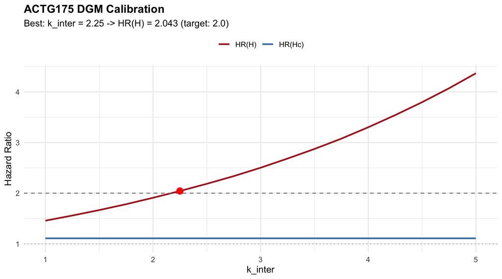

Calibration of k_inter: HR(H) as a function of the interaction parameter.

```r
ggplot(cal_valid, aes(x = k_inter)) +
  geom_line(aes(y = hr_H,  colour = "HR(H)"),  linewidth = 1) +
  geom_line(aes(y = hr_Hc, colour = "HR(Hc)"), linewidth = 1) +
  geom_hline(yintercept = cal_target_hr, linetype = "dashed",
             colour = "grey50") +
  geom_hline(yintercept = 1.0, linetype = "dotted",
             colour = "grey70") +
  geom_point(
    data = cal_valid[best_idx, ],
    aes(x = k_inter, y = hr_H),
    colour = "red", size = 4, shape = 16
  ) +
  scale_colour_manual(
    values = c("HR(H)" = "firebrick", "HR(Hc)" = "steelblue")
  ) +
  labs(
    x = "k_inter",
    y = "Hazard Ratio",
    title = "ACTG175 DGM Calibration",
    subtitle = sprintf(
      "Best: k_inter = %.2f -> HR(H) = %.3f (target: %.1f)",
      k_inter_best, cal_valid$hr_H[best_idx], cal_target_hr
    ),
    colour = NULL
  ) +
  theme_minimal(base_size = 12) +
  theme(legend.position = "top",
        plot.title = element_text(face = "bold"))
```

## 4.4 Step 4: Create Calibrated DGM

```r
t0 <- proc.time()[3]

dgm_calibrated <- generate_aft_dgm_flex(
  data            = dfa,
  outcome_var     = "y",
  event_var       = "event",
  treatment_var   = "treat",
  continuous_vars = dgm_continuous_vars,
  factor_vars     = dgm_factor_vars,
  subgroup_vars   = dgm_subgroup_vars,
  subgroup_cuts   = dgm_subgroup_cuts,
  model           = "alt",
  k_inter         = k_inter_best,
  k_treat         = dgm_k_treat,
  n_super         = dgm_n_super,
  seed            = sim_seed,
  verbose         = TRUE
)
```

```
#>
#> === Subgroup Definitions ===
#>    z1 == 1
#>     Proportion in subgroup: 0.488
#>    z2 == 1
#>     Proportion in subgroup: 0.75
#>
#> Overall subgroup (all conditions met):
#>   Size: 382 out of 1083
#>   Proportion: 0.353
#>
#> === Model Parameters (AFT, log(T)) ===
#> Intercept (mu): 4.449
#> Scale (tau): 0.602
#> Treatment effect: -0.072
#> Interaction effect: -0.431
#>
#> Overall subgroup in super-population (all conditions met):
#>   Proportion: 0.345
#>
#> === Hazard Ratios (super popln) ===
#> Overall HR: 1.332
#> Causal AHR: 1.443
#> Harm subgroup HR: 2.043
#> Harm subgroup AHR: 2.308
#> No-harm subgroup HR: 1.109
#> No-harm subgroup AHR: 1.127
#>
#>  ======================================================================
#>  CENSORING MODEL SELECTION:
#>  MULTIPLE SURVIVAL REGRESSION MODEL COMPARISONS
#> ======================================================================
#>
#> CONVERGENCE SUMMARY ( 4 / 4  converged):
#> --------------------------------------------------
#>
#> Weibull (weibull):
#>   Status:  ✓ Converged
#>   Iterations:  24
#>   Log-likelihood:  -2823.686
```

[output cut: 28 more lines]

```
#> MODEL RANKINGS:
#> --------------------------------------------------
#> By AIC:  Weibull > Weibull0 > LogNormal > LogNormal0
#> By BIC:  Weibull0 > Weibull > LogNormal0 > LogNormal
#>
#> EVIDENCE ASSESSMENT:
#> --------------------------------------------------
#>   Strength:  Strong evidence
#>   Details:  Top model has 98.4% of AIC weight
#>
#> FINAL RECOMMENDATION:
#> --------------------------------------------------
#>   Recommended: Weibull (overwhelming AIC support: 98.4%)
#>   Note: BIC prefers Weibull0 but AIC evidence is very strong
#> ======================================================================
```

```r
# Enrich with CDE potential outcomes (required for estimation tables)
dgm_calibrated <- compute_dgm_cde(dgm_calibrated)
dgm_calibrated <- add_compat_aliases(dgm_calibrated)

cat("\n=== Calibrated ACTG175 DGM ===\n")
```

```
#>
#> === Calibrated ACTG175 DGM ===
```

```r
cat("  HR(H):",   round(dgm_calibrated$hazard_ratios$harm_subgroup,      3), "\n")
```

```
#>   HR(H): 2.043
```

```r
cat("  HR(Hc):",  round(dgm_calibrated$hazard_ratios$no_harm_subgroup,     3), "\n")
```

```
#>   HR(Hc): 1.109
```

```r
cat("  HR(ITT):", round(dgm_calibrated$hazard_ratios$overall, 3), "\n")
```

```
#>   HR(ITT): 1.332
```

```r
timings$dgm_calibrated <- proc.time()[3] - t0
```

## 4.5 Step 5: Create Null DGM

Under `model = "null"`, the treatment effect is **homogeneous** across all patients — no treatment effect heterogeneity. Treatment is still beneficial for everyone; there is simply no subgroup with a different treatment effect. Any subgroup detected under the null is a false positive.

By default, `k_treat = 1` preserves the fitted ITT treatment effect. For the benefit-search / switched-treatment setup here, the fitted switched-scale ITT HR is the reciprocal of the original beneficial HR. If the original HR = 0.84, the switched HR = 1/0.84 = 1.19. This sits below the threshold (c1 = 1.667) but the gap is narrower than in harm-search scenarios. The default behaviour (preserved fitted ITT effect) is the conservative, realistic choice; the $L_\text{eff}$ calibration procedure accounts for this when selecting thresholds.

**NoteOptional: widen the gap from c1 with `null_target_hr`**

If you want to study type-I-error inflation **in isolation** of the proximity to c1, you can target a specific switched-scale ITT HR for the null DGM by setting `null_target_hr` in the setup chunk. The code below solves for the `k_treat` value that produces the requested target.

The solver is approximate: `k_treat` multiplies the AFT log-time treatment coefficient, but the realised Cox HR also depends on the censoring distribution and the covariate distribution, so the constructed HR will be close to but not exactly equal to `null_target_hr`. After construction we re-check the realised ITT HR; if it is materially off, iterate.

This is **not** a different research question – the topic remains differential treatment effects across subgroups. It is simply a way to widen the gap between the marginal ITT HR and c1 so that the FPR you measure is driven by search-space multiplicity rather than by the marginal signal sitting close to the detection threshold.

Setting `null_target_hr = NULL` (the default) preserves the fitted ITT effect (`k_treat = 1`).

```r
t0 <- proc.time()[3]

# ── Solve for k_treat under the optional null_target_hr ──────────
# The default keeps k_treat = dgm_k_treat (typically 1.0, preserving
# the fitted ITT effect).  When null_target_hr is non-NULL, we solve:
#   k_treat_null = log(target_hr_switched) / log(fitted_hr_switched)
# fitted_hr_switched comes from the alt DGM's overall hazard ratio,
# which is on the switched scale by construction in this vignette.
dgm_k_treat_null <- dgm_k_treat
if (!is.null(null_target_hr)) {
  fitted_log_hr <- log(dgm_alt$hazard_ratios$overall)
  if (abs(fitted_log_hr) < 1e-8) {
    stop("Fitted ITT log-HR is ~0; cannot rescale to a target HR. ",
         "Leave null_target_hr = NULL.")
  }
  dgm_k_treat_null <- log(null_target_hr) / fitted_log_hr
  message(sprintf(
    "null_target_hr = %.3f  -->  k_treat (null) = %.3f  (fitted log-HR = %.3f)",
    null_target_hr, dgm_k_treat_null, fitted_log_hr))
}

dgm_null <- generate_aft_dgm_flex(
  data            = dfa,
  outcome_var     = "y",
  event_var       = "event",
  treatment_var   = "treat",
  continuous_vars = dgm_continuous_vars,
  factor_vars     = dgm_factor_vars,
  subgroup_vars   = dgm_subgroup_vars,
  subgroup_cuts   = dgm_subgroup_cuts,
  model           = "null",
  k_treat         = dgm_k_treat_null,
  n_super         = dgm_n_super,
  seed            = sim_seed,
  verbose         = TRUE
)
```

```
#>
#> === Model Parameters (AFT, log(T)) ===
#> Intercept (mu): 4.525
#> Scale (tau): 0.603
#> Treatment effect: -0.137
#>
#> Overall subgroup in super-population (all conditions met):
#>   Proportion: 0
#>
#> === Hazard Ratios (super popln) ===
#> Overall HR: 1.215
#> Causal AHR: 1.255
#>
#>  ======================================================================
#>  CENSORING MODEL SELECTION:
#>  MULTIPLE SURVIVAL REGRESSION MODEL COMPARISONS
#> ======================================================================
#>
#> CONVERGENCE SUMMARY ( 4 / 4  converged):
#> --------------------------------------------------
#>
#> Weibull (weibull):
#>   Status:  ✓ Converged
#>   Iterations:  24
#>   Log-likelihood:  -2823.686
#>   Scale parameter:  0.1413
#>
#> LogNormal (lognormal):
#>   Status:  ✓ Converged
#>   Iterations:  4
#>   Log-likelihood:  -3297.547
#>   Scale parameter:  0.3485
#>
#> Weibull0 (weibull):
#>   Status:  ✓ Converged
#>   Iterations:  10
#>   Log-likelihood:  -2839.781
#>   Scale parameter:  0.1439
#>
#> LogNormal0 (lognormal):
```

[output cut: 13 more lines]

```
#> MODEL RANKINGS:
#> --------------------------------------------------
#> By AIC:  Weibull > Weibull0 > LogNormal > LogNormal0
#> By BIC:  Weibull0 > Weibull > LogNormal0 > LogNormal
#>
#> EVIDENCE ASSESSMENT:
#> --------------------------------------------------
#>   Strength:  Strong evidence
#>   Details:  Top model has 98.4% of AIC weight
#>
#> FINAL RECOMMENDATION:
#> --------------------------------------------------
#>   Recommended: Weibull (overwhelming AIC support: 98.4%)
#>   Note: BIC prefers Weibull0 but AIC evidence is very strong
#> ======================================================================
```

```r
dgm_null <- add_compat_aliases(dgm_null)

cat("\n=== ACTG175 Null DGM ===\n")
```

```
#>
#> === ACTG175 Null DGM ===
```

```r
cat("  k_treat used:           ", round(dgm_k_treat_null, 3), "\n")
```

```
#>   k_treat used:            1
```

```r
if (!is.null(null_target_hr)) {
  cat("  null_target_hr (target):", round(null_target_hr, 3), "\n")
}
cat("  HR(ITT, switched):      ", round(dgm_null$hazard_ratios$overall, 3), "\n")
```

```
#>   HR(ITT, switched):       1.215
```

```r
cat("  HR(ITT, original):      ", round(1 / dgm_null$hazard_ratios$overall, 3), "\n")
```

```
#>   HR(ITT, original):       0.823
```

```r
cat("  c1 threshold:           ", fs_hr_threshold, "\n")
```

```
#>   c1 threshold:            1.667
```

```r
cat(sprintf("  Gap (c1 - HR_switched):  %.3f\n",
            fs_hr_threshold - dgm_null$hazard_ratios$overall))
```

```
#>   Gap (c1 - HR_switched):  0.452
```

```r
timings$dgm_null <- proc.time()[3] - t0
```

### 4.5.1 Illustrative `k_treat` values: HR(ITT) and gap to c1

To give the reader a concrete sense of how `k_treat` controls the marginal ITT effect and therefore the gap from c1, the table below constructs three illustrative null DGMs at `k_treat` $\in \{0.5, 1.0, 1.5\}$ using the same data, factor lists, super-population size, and seed as the main `dgm_null` above. The default (`k_treat = 1.0`) preserves the fitted ITT effect; **larger** `k_treat` amplifies the marginal benefit, pushing the switched-scale HR further above 1 and *narrowing* the gap to c1; **smaller** `k_treat` attenuates the marginal effect toward HR $\approx 1$ and *widens* the gap.

**Build three illustrative null DGMs and tabulate (click to expand)**

```r
# Three illustrative null DGMs.  These are NOT used in the simulation
# loop below; the simulation uses `dgm_null` from the previous chunk
# (constructed with k_treat = dgm_k_treat_null).  The grid here is
# purely a didactic table so the reader can see how k_treat moves
# HR(ITT) and the gap to c1.
k_treat_grid <- c(0.5, 1.0, 1.5)

illust_rows <- lapply(k_treat_grid, function(k) {
  d <- generate_aft_dgm_flex(
    data            = dfa,
    outcome_var     = "y",
    event_var       = "event",
    treatment_var   = "treat",
    continuous_vars = dgm_continuous_vars,
    factor_vars     = dgm_factor_vars,
    subgroup_vars   = dgm_subgroup_vars,
    subgroup_cuts   = dgm_subgroup_cuts,
    model           = "null",
    k_treat         = k,
    n_super         = dgm_n_super,
    seed            = sim_seed,
    verbose         = FALSE
  )
  d <- add_compat_aliases(d)
  hr_switched <- as.numeric(d$hazard_ratios$overall)
  data.frame(
    k_treat     = k,
    hr_switched = hr_switched,
    hr_original = 1 / hr_switched,
    gap_to_c1   = fs_hr_threshold - hr_switched
  )
})
illust_tbl <- do.call(rbind, illust_rows)

gt::gt(illust_tbl) |>
  gt::tab_header(
    title    = "Illustrative null DGMs: HR(ITT) and gap to c1 by k_treat",
    subtitle = sprintf(
      "ACTG175 benefit search, switched scale; c1 = %.3f, n_super = %d",
      fs_hr_threshold, dgm_n_super
    )
  ) |>
  gt::cols_label(
    k_treat     = "k_treat",
    hr_switched = "HR(ITT, switched)",
    hr_original = "HR(ITT, original)",
    gap_to_c1   = gt::md("Gap (c1 \u2212 HR_switched)")
  ) |>
  gt::fmt_number(
    columns  = c(hr_switched, hr_original, gap_to_c1),
    decimals = 3
  ) |>
  gt::fmt_number(columns = k_treat, decimals = 1) |>
  gt::tab_style(
    style    = gt::cell_text(weight = "bold"),
    locations = gt::cells_body(rows = k_treat == 1.0)
  ) |>
  gt::tab_footnote(
    footnote = paste0(
      "k_treat = 1.0 (bold row) preserves the fitted ITT effect; this is ",
      "the default null DGM. Smaller k_treat attenuates the marginal ",
      "effect toward HR \u2248 1 (widening the gap to c1); larger k_treat ",
      "amplifies the effect (narrowing the gap). The realised HR is ",
      "approximate -- the AFT log-time scaling does not map exactly to ",
      "the Cox HR, which also depends on the censoring and covariate ",
      "distributions."
    )
  )
```

Illustrative null DGMs: HR(ITT) and gap to c1 by k_treat

ACTG175 benefit search, switched scale; c1 = 1.667, n_super = 5000

| k_treat | HR(ITT, switched) | HR(ITT, original) | Gap (c1 − HR_switched) |
| --- | --- | --- | --- |
| 0.5 | 1.103 | 0.907 | 0.564 |
| 1.0 | 1.215 | 0.823 | 0.452 |
| 1.5 | 1.339 | 0.747 | 0.328 |

k_treat = 1.0 (bold row) preserves the fitted ITT effect; this is the default null DGM. Smaller k_treat attenuates the marginal effect toward HR ≈ 1 (widening the gap to c1); larger k_treat amplifies the effect (narrowing the gap). The realised HR is approximate -- the AFT log-time scaling does not map exactly to the Cox HR, which also depends on the censoring and covariate distributions.

# 5 Single Trial Simulation

Before running the full simulation study, we generate a single simulated trial to verify that the pipeline produces sensible data. This is a useful sanity check: the simulated event rate, subgroup prevalence, and ITT HR should be broadly consistent with the DGM parameters.

```r
sim_data <- simulate_from_dgm(
  dgm           = dgm_calibrated,
  n             = single_n,
  rand_ratio    = single_rand_ratio,
  seed          = single_seed,
  analysis_time = sim_analysis_time,
  cens_adjust   = sim_cens_adjust
)

cat("Simulated ACTG175 trial:\n")
```

```
#> Simulated ACTG175 trial:
```

```r
cat("  N =", nrow(sim_data), "\n")
```

```
#>   N = 1000
```

```r
cat("  Events =", sum(sim_data$event_sim),
    sprintf("(%.1f%%)\n", 100 * mean(sim_data$event_sim)))
```

```
#>   Events = 200 (20.0%)
```

```r
cat("  Harm subgroup size =", sum(sim_data$flag_harm),
    sprintf("(%.1f%%)\n", 100 * mean(sim_data$flag_harm)))
```

```
#>   Harm subgroup size = 328 (32.8%)
```

```r
fit_sim <- coxph(Surv(y_sim, event_sim) ~ treat_sim, data = sim_data)
cat("  Estimated ITT HR =", round(exp(coef(fit_sim)), 3), "\n")
```

```
#>   Estimated ITT HR = 1.85
```

## 5.1 Censoring Diagnostic

The `check_censoring_dgm()` function compares the simulated censoring distribution against the observed data used to build the DGM. Large discrepancies suggest a time-scale mismatch or a poorly calibrated censoring model.

```r
check_censoring_dgm(
  sim_data = sim_data,
  dgm      = dgm_calibrated
)
```

```
#>
#> =========================================================
#>   Censoring Diagnostic: DGM Reference vs Simulated
#> =========================================================
#>   DGM censoring type  : weibull
#>   DGM mu_cens         : 3.5834  [exp = 35.99 time units]
#>   DGM tau_cens        : 0.1413
#>   Reference n (super) : 5000
#>   Simulated n         : 1000
#>
#> --- 1. Censoring Rates ---
#>    Group Ref_rate Sim_rate    Diff
#>  Overall    78.0%    80.0% +2.0 pp
#>    Arm 0    79.5%    85.4% +5.9 pp
#>    Arm 1    76.6%    74.6% -2.0 pp
#>
#> --- 2. Censoring-Time Quantiles (censored subjects only) ---
#>     Ref: y[event == 0]  |  Sim: c_time[event_sim == 0]
#>  Quantile   Ref   Sim Ratio
#>       25% 32.00 26.41 0.825
#>       50% 34.63 30.00 0.866
#>       75% 36.63 33.76 0.922
#>       90% 37.91 36.42 0.961
#>
#> --- 3. KM Median Censoring Time (reversed event indicator) ---
#>    Group Ref_median Sim_median Ratio
#>  Overall   34.79261   30.25479 0.870
#>    Arm 0   34.95688   30.25786 0.866
#>    Arm 1   34.66119   30.17045 0.870
#>
#> --- 4. Implied Time-Scale Check ---
#>   exp(params$mu)          = 85.54  [median outcome time, DGM scale]
#>   exp(params$censoring$mu)= 35.99  [median censoring time, DGM scale]
#>   If these values are implausibly large relative to your
#>   analysis_time, the DGM was likely built on a different time
#>   scale (e.g. days vs months).
#>
#> [OK] No substantial discrepancies detected.
#> =========================================================
```

## 5.2 Baseline Characteristics (Simulated Trial)

```r
# Label treatment arms for the table
sim_data$treat_label <- factor(
  sim_data$treat_sim,
  levels = c(0, 1),
  labels = c("Combo (ZDV+ddI)", "ddI monotherapy")
)

# Simulated data has z1-z12 as factor columns from the DGM super-population.
# Identify which z-variables are present
z_vars <- grep("^z[0-9]+$", names(sim_data), value = TRUE)
z_vars_present <- z_vars[z_vars %in% names(sim_data)]

create_summary_table(
  data       = sim_data,
  treat_var  = "treat_label",
  vars_continuous  = "y_sim",
  vars_categorical = z_vars_present,
  var_labels = c(y_sim = "Follow-up time (months)"),
  table_title = "Simulated Trial: Baseline Characteristics by Treatment Arm",
  table_subtitle = sprintf("N = %d, Events = %d (%.1f%%)",
    nrow(sim_data), sum(sim_data$event_sim),
    100 * mean(sim_data$event_sim)),
  font_size = 11
)
```

Simulated Trial: Baseline Characteristics by Treatment Arm

N = 1000, Events = 200 (20.0%)

| Characteristic |  | Control (n=500) | Treatment (n=500) | P-value<sup>1</sup> | SMD<sup>2</sup> |
| --- | --- | --- | --- | --- | --- |
| Follow-up time (months) | Mean (SD) | 28.5 (6.7) | 27.1 (8.0) | 0.004 | 0.18 |
| z30 |  | 268 (53.6%) | 260 (52.0%) | 0.657 | 0.03 |
| z1 |  | 232 (46.4%) | 233 (46.6%) | 1.000 | 0.00 |
| z2 |  | 364 (72.8%) | 395 (79.0%) | 0.027 | 0.15 |
| z3 |  | 251 (50.2%) | 251 (50.2%) | 1.000 | 0.00 |
| z4 |  |  |  |  |  |
|  | 1 | 500 (100.0%) | 500 (100.0%) |  |  |
| z5 |  | 251 (50.2%) | 254 (50.8%) | 0.899 | 0.01 |
| z6 |  | 261 (52.2%) | 259 (51.8%) | 0.950 | 0.01 |
| z7 |  | 45 (9.0%) | 47 (9.4%) | 0.913 | 0.01 |
| z8 |  | 341 (68.2%) | 315 (63.0%) | 0.096 | 0.11 |
| z9 |  | 61 (12.2%) | 70 (14.0%) | 0.453 | 0.05 |
| z10 |  | 120 (24.0%) | 153 (30.6%) | 0.023 | 0.15 |
| z11 |  | 417 (83.4%) | 416 (83.2%) | 1.000 | 0.01 |
| z12 |  | 82 (16.4%) | 88 (17.6%) | 0.674 | 0.03 |

<sup>1</sup> P-values: t-test for continuous, chi-square/Fisher's exact for categorical/binary variables  
<sup>2</sup> SMD = Standardized mean difference (Cohen's d for continuous, Cramer's V for categorical)

## 5.3 Kaplan-Meier Analysis (Simulated Trial)

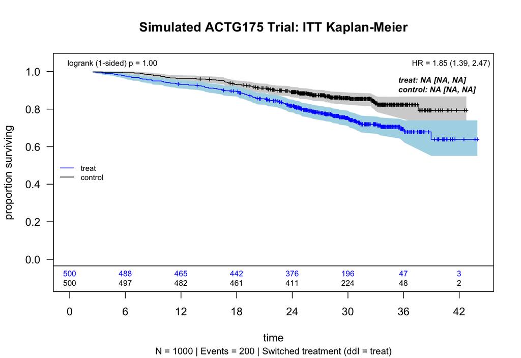

Kaplan-Meier curves for a single simulated ACTG175 trial (switched treatment scale).

```r
dfcount_sim <- weightedsurv::df_counting(
  df        = sim_data,
  by.risk   = fs_by_risk,
  tte.name  = "y_sim",
  event.name = "event_sim",
  treat.name = "treat_sim"
)
weightedsurv::plot_weighted_km(
  dfcount_sim,
  conf.int     = TRUE,
  show.logrank = TRUE,
  ymax         = 1.05,
  xmed.fraction = 0.775,
  ymed.offset   = 0.125
)
title(main = "Simulated ACTG175 Trial: ITT Kaplan-Meier",
      sub  = sprintf("N = %d | Events = %d | Switched treatment (ddI = treat)",
                      nrow(sim_data), sum(sim_data$event_sim)),
      cex.sub = 0.85)
```

```r
fit_sim_adj <- coxph(
  Surv(y_sim, event_sim) ~ treat_sim + z1 + z2 + z3,
  data = sim_data
)

cat("=== Single Simulated Trial: Cox PH Summary ===\n")
```

```
#> === Single Simulated Trial: Cox PH Summary ===
```

```r
cat(sprintf("  Unadjusted HR: %.3f\n", exp(coef(coxph(
  Surv(y_sim, event_sim) ~ treat_sim, data = sim_data)))))
```

```
#>   Unadjusted HR: 1.850
```

```r
cat(sprintf("  Adjusted HR:   %.3f (z1 + z2 + z3)\n",
    exp(coef(fit_sim_adj)["treat_sim"])))
```

```
#>   Adjusted HR:   1.849 (z1 + z2 + z3)
```

## 5.4 ForestSearch on Simulated Trial

**WarningSingle-replicate caveat: realistic-analysis variance**

Because the analysis methods see covariates in their RAW form (not the discretised z-factors), variable-screening steps such as LASSO and GRF must rediscover the truth-defining variables from scratch in each replicate. Under modest sample sizes (n = 1000 per trial here), it is **expected** that any single replicate may fail to retain the true subgroup-defining variables – this is the price of the realistic-analysis pattern, not a bug.

Reliable inference about the method’s behaviour comes from the **full simulation loop** in Section 7, where the operating characteristics aggregate across 50 simulations. The H1 detection rate, classification metrics, and bias diagnostics in Section 7.2 are the appropriate basis for evaluating the method; the single-replicate output below is a pipeline-sanity check, not a performance claim.

```r
t0 <- proc.time()[3]

fs_single <- tryCatch(
  suppressWarnings(forestsearch(
    df.analysis            = sim_data,
    confounders.name       = confounders_analysis,
    outcome.name           = "y_sim",
    event.name             = "event_sim",
    treat.name             = "treat_sim",
    id.name                = "id",
    hr.threshold           = fs_hr_threshold,
    hr.consistency         = fs_hr_consistency,
    pconsistency.threshold = fs_pconsistency_thresh,
    fs.splits              = fs_splits,
    n.min                  = fs_n_min,
    d0.min                 = fs_d0_min,
    d1.min                 = fs_d1_min,
    maxk                   = fs_maxk,
    by.risk                = fs_by_risk,
    vi.grf.min             = fs_vi_grf_min,
    use_lasso              = TRUE,
    use_grf                = TRUE,
    is.RCT                 = TRUE,
    details                = TRUE,
    quiet                  = FALSE,
    seedit                 = sim_seed,
    parallel_args          = list(
      plan = "sequential", workers = 1, show_message = FALSE
    )
  )),
  error = function(e) {
    warning("ForestSearch failed: ", e$message)
    NULL
  }
)
```

```
#>
#> [forestsearch] Subgroup Identification Configuration
#>   Outcome type:   survival (Cox PH)
#>   Effect measure: HR (hazard ratio)
#>   Scale:          log (ratio)
#>
#>   Screening:      HR >= 1.67  (log: 0.5110)
#>   Consistency:    HR >= 1.25  (log: 0.2231)
#>   Consistency rate threshold: 90%
#>
#>   Interpretation:
#>     Candidates: subgroup hazard ratio >= 1.67
#>     Splits:     each split HR >= 1.25
```

```
#>   Search Alignment Diagnostic
```

```
#>
#>   Outcome:    y_sim (survival)
```

```
#>   Treatment:  treat_sim
```

```
#>   Measure:    Hazard Ratio (HR)
```

```
#>
#>   ForestSearch searches for:
#>     Subgroups where treat_sim increases the event hazard
#>     (HR >= threshold in the candidate subgroup)
```

```
#>
#>   Thresholds:
#>     Screening: HR >= 1.667 in the candidate subgroup
#>     Consistency: HR >= 1.250 in each bootstrap split
```

```
#>
#>   Variable screening:
```

```
#>     LASSO: LASSO screening uses glmnet with family = "Cox (coxnet)".
#>     Variables with non-zero coefficients are retained.
```

```
#>     GRF:   causal_survival_forest() estimates treatment effect on
#>     survival probability. Positive CATE = treatment increases
#>     survival = treatment HELPS (events assumed adverse).
```

```
#>
#>   No alignment concerns detected.
```

```
#> GRF subgroup: cd80 <= 1682
#> GRF cuts identified: 3
#>   Cuts: age <= 30, wtkg <= 86.18, cd80 <= 1682
#> Cox-LASSO selected: 3 of 12 candidate factors
#>   Omitted: age, preanti, wtkg, karnof, cd80, homo, drugs, race, gender
#> Candidate factors: 9
#> [1] "age <= 30"     "wtkg <= 86.18" "cd80 <= 1682"  "cd40 <= 346.3"
#> [5] "cd40 <= 336"   "cd40 <= 258.8" "cd40 <= 420"   "hemo"
#> [9] "symptom"
#> Number of possible configurations (<= maxk): maxk = 2 , # combinations = 171
#> Per-arm events criteria: control >= 10, treatment >= 10
#> Sample size criteria: n >= 60
#> Subgroup search completed in 0.01 minutes
#>
#> --- Filtering Summary ---
#>   Combinations evaluated: 171
#>   Passed variance check: 156
#>   Passed prevalence (>= 0.025 ): 156
#>   Passed redundancy check: 149
#>   Passed events counts (d0>= 10, d1>= 10): 99
#>   Passed sample size (n>= 60 ): 99
#>   Cox model fit successfully: 99
#>   Passed effect threshold (effect >= 1.6670): 59
#> -------------------------
#>
#> Found 59 subgroup candidate(s)
#> # of candidate subgroups (meeting all criteria) = 59
#> # of unique initial candidates: 59
#> # Restricting to top stop_Kgroups = 10
#> # of candidates to evaluate: 10
#> # Early stop threshold: 0.95
#> Parallel config: workers = 1 , batch_size = 1
#> Batch 1 / 10 : candidates 1 - 1
#>
#> ==================================================
#> EARLY STOP TRIGGERED (batch 1 )
#>   Candidate: 1 of 10
#>   Pcons: 1 >= 0.95
#> ==================================================
#>
#> Evaluated 1 of 10 candidates (early stop)
#> 1 subgroups passed consistency threshold
#> SG focus = hr
#> Seconds and minutes forestsearch overall = 1.242 0.0207
#> Consistency algorithm used: twostage
#> Subgroup identified: {cd40 <= 258.8} & !{age <= 30}
```

```r
timings$single_fs <- proc.time()[3] - t0
cat(sprintf("\nForestSearch completed in %.1f sec\n", timings$single_fs))
```

```
#>
#> ForestSearch completed in 1.2 sec
```

```r
fs_single_detected <- !is.null(fs_single) &&
  !is.null(fs_single$grp.consistency) &&
  !is.null(fs_single$grp.consistency$sg.harm.id) &&
  length(fs_single$grp.consistency$sg.harm.id) > 0

if (fs_single_detected) {
  sg_id <- fs_single$grp.consistency$sg.harm.id
  cat("=== ForestSearch Result (Single Simulated Trial) ===\n")
  cat("  Subgroup:", paste(sg_id, collapse = " & "), "\n")

  df_est <- fs_single$df.est
  in_H   <- df_est$treat.recommend == 0
  true_Q <- sim_data$flag_harm == 1

  tp <- sum(in_H & true_Q); fp <- sum(in_H & !true_Q)
  fn <- sum(!in_H & true_Q); tn <- sum(!in_H & !true_Q)
  cat(sprintf("  n(H) = %d (%.1f%%), n(Hc) = %d\n",
      sum(in_H), 100 * mean(in_H), sum(!in_H)))
  cat(sprintf("  Sensitivity: %.3f\n", tp / max(tp + fn, 1)))
  cat(sprintf("  Specificity: %.3f\n", tn / max(tn + fp, 1)))
  cat(sprintf("  PPV:         %.3f\n", tp / max(tp + fp, 1)))
} else {
  cat("ForestSearch did not identify a subgroup in this single trial.\n")
  cat("This can happen with moderate effect sizes at n =", single_n, "\n")
}
```

[output not shown]

### 5.4.1 KM by Identified Subgroups

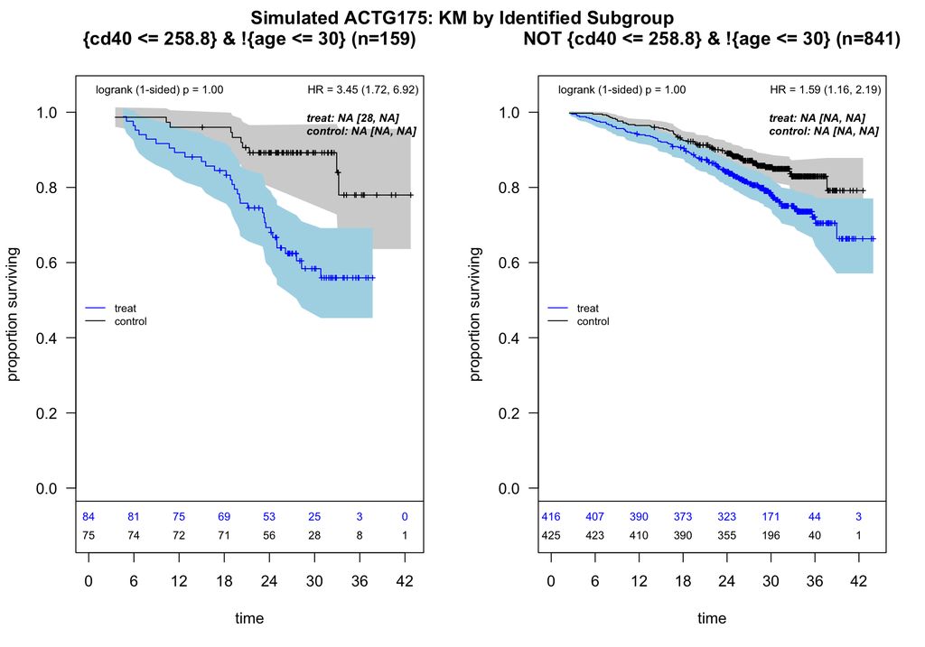

Kaplan-Meier curves by ForestSearch-identified subgroup (single simulated trial).

```r
if (fs_single_detected) {
  km_result <- plot_sg_weighted_km(
    fs.est       = fs_single,
    outcome.name = "y_sim",
    event.name   = "event_sim",
    treat.name   = "treat_sim",
    by.risk      = fs_by_risk,
    conf.int     = TRUE,
    show.logrank = TRUE,
    show.cox     = TRUE,
    show.cox.bc  = FALSE,
    ymax         = 1.05,
    xmed.fraction = 0.65,
    title        = "Simulated ACTG175: KM by Identified Subgroup"
  )
} else {
  cat("No subgroup identified -- KM plot skipped.\n")
}
```

**Note**

The subgroup identified in this single trial may differ from the true $Q$ defined by the DGM. The simulation study below evaluates how often ForestSearch correctly recovers the true subgroup across many replicates.

# 6 Running Simulation Studies

## 6.1 Setup

```r
plan(multisession, workers = n_workers)
cat("Using", n_workers, "parallel workers\n")
```

```
#> Using 12 parallel workers
```

```r
# ── Candidate variable set ────────────────────────────────────
# confounders_base tells run_simulation_analysis() which columns in
# the simulated data to pass to ForestSearch and GRF as candidate
# subgroup-defining variables.  Mirrors the binary vignette: a real
# analyst would NOT know which variables define Q nor where to cut
# them, so the candidate set is the RAW continuous columns
# (age, preanti, wtkg, karnof, cd40, cd80) plus the truly-binary
# factor columns (hemo, homo, drugs, race, gender, symptom).  The
# discretised z1-z12 columns remain on the simulated data frame
# only for the DGM (via factor_vars) and the truth flag --- they
# are NOT candidates for the analysis search.
confounders_actg <- confounders_analysis

# ── ForestSearch parameters ───────────────────────────────────
# These are passed to run_simulation_analysis() and forwarded to
# forestsearch().  The annotations below explain each parameter
# and when you might change it for your own study.
fs_params <- list(
  # Column name mappings — must match simulate_from_dgm() output
  outcome.name           = "y_sim",
  event.name             = "event_sim",
  treat.name             = "treat_sim",
  id.name                = "id",

  # Variable screening flags
  use_lasso              = TRUE,    # LASSO pre-screening (recommended)
  use_grf                = TRUE,    # GRF pre-screening (recommended)

  # Subgroup detection thresholds (see Leon et al. 2024, Section 3)
  # c1: a candidate subgroup must have HR > hr.threshold to be flagged.
  # Increase for more conservative detection; decrease for more power.
  hr.threshold           = fs_hr_threshold,
  # c2: in each bootstrap replicate, the subgroup HR must exceed this
  # value.  Typically set to 1.0 (any harm signal).
  hr.consistency         = fs_hr_consistency,
  # The proportion of bootstrap replicates in which the subgroup HR
  # exceeds c2.  The paper default is 0.90.
  pconsistency.threshold = fs_pconsistency_thresh,

  # Computational and sample-size constraints
  fs.splits              = fs_splits,    # Bootstrap replicates (400 is default)
  n.min                  = fs_n_min,     # Minimum subgroup size (both arms)
  d0.min                 = fs_d0_min,    # Minimum events, control arm
  d1.min                 = fs_d1_min,    # Minimum events, treatment arm
  maxk                   = fs_maxk,      # Max subgroup-defining variables
  by.risk                = fs_by_risk,   # Risk-table granularity (time units)
  vi.grf.min             = fs_vi_grf_min, # GRF variable importance threshold
  seedit                 = sim_seed,      # Reproducible split-half consistency

  # Two-stage estimation: after identifying a subgroup, re-estimates
  # the treatment effect using an independent hold-out sample.
  # Recommended for bias correction.
  use_twostage           = TRUE,
  twostage_args          = list(),

  # GRF tuning (applies to ForestSearch's internal GRF pre-screening)
  tune_grf               = grf_tune,

  # Inner parallelism: ForestSearch runs sequentially within each
  # worker.  The outer loop (foreach) parallelises across replicates.
  parallel_args          = list(
    plan = "sequential", workers = 1, show_message = FALSE
  )
)

# -- GRF standalone parameter overrides ----------------------------------------
grf_params <- list(
  dmin.grf     = grf_dmin,
  frac.tau     = grf_frac_tau,
  maxdepth     = grf_maxdepth,
  sg.criterion = grf_sg_criterion,
  tune_grf     = grf_tune
)

# ── Simulation configuration ─────────────────────────────────
sim_config <- list(
  n_sample      = sim_n_sample,
  analysis_time = sim_analysis_time,
  cens_adjust   = sim_cens_adjust
)
```

## 6.2 Alternative Hypothesis Simulations

```r
cat("Running", nsims_alt, "simulations under H1...\n")
```

```
#> Running 50 simulations under H1...
```

```r
t0 <- proc.time()[3]

results_alt_raw <- foreach(
  sim = seq_len(nsims_alt),
  .errorhandling = "pass",
  .options.future = list(
    packages = c("forestsearch", "survival", "data.table", "future"),
    seed = TRUE
  )
) %dofuture% {
  # Reset plan inside workers to prevent nested parallelism.
  # Each worker runs ForestSearch sequentially; the outer foreach
  # loop parallelises across simulation replicates.
  future::plan("sequential")
  run_simulation_analysis(
    sim_id           = sim,
    dgm              = dgm_calibrated,
    n_sample         = sim_config$n_sample,
    analysis_time    = sim_config$analysis_time,
    cens_adjust      = sim_config$cens_adjust,
    confounders_base = confounders_actg,
    cox_formula_adj  = cox_formula_adj,
    n_add_noise      = sim_n_noise,
    run_fs           = run_fs,
    run_fs_grf       = run_fs_grf,
    run_grf          = run_grf,
    fs_params        = fs_params,
    grf_params       = grf_params,
    verbose          = FALSE
  )
}

timings$sims_alt <- proc.time()[3] - t0
results_alt <- forestsearch::collect_results(results_alt_raw, "H1 alt")
n_failed_alt <- attr(results_alt, "n_failed")
cat("Completed in", round(timings$sims_alt / 60, 1), "minutes\n")
```

```
#> Completed in 0.6 minutes
```

```r
if (n_failed_alt > 0) cat(sprintf("  *** %d FAILED ***\n", n_failed_alt))
cat("Results:", nrow(results_alt), "rows\n")
```

```
#> Results: 100 rows
```

## 6.3 Null Hypothesis Simulations

```r
# Reset worker pool between alt and null phases to prevent memory
# accumulation and worker bloat (null sims on bloated workers can be
# ~20x slower).  reset_workers() is exported from forestsearch v0.2.0.
forestsearch::reset_workers(workers = n_workers)
```

```
#> reset_workers: plan reset to FutureStrategy with 12 worker(s) (was FutureStrategy).
```

```r
cat("Running", nsims_null, "simulations under H0...\n")
```

```
#> Running 200 simulations under H0...
```

```r
t0 <- proc.time()[3]

results_null_raw <- foreach(
  sim = seq_len(nsims_null),
  .errorhandling = "pass",
  .options.future = list(
    packages = c("forestsearch", "survival", "data.table", "future"),
    seed = TRUE
  )
) %dofuture% {
  # Reset plan inside workers to prevent nested parallelism.
  future::plan("sequential")
  run_simulation_analysis(
    sim_id           = sim,
    dgm              = dgm_null,
    n_sample         = sim_config$n_sample,
    analysis_time    = sim_config$analysis_time,
    cens_adjust      = sim_config$cens_adjust,
    confounders_base = confounders_actg,
    cox_formula_adj  = cox_formula_adj,
    n_add_noise      = sim_n_noise,
    run_fs           = run_fs,
    run_fs_grf       = run_fs_grf,
    run_grf          = run_grf,
    fs_params        = fs_params,
    grf_params       = grf_params,
    verbose          = FALSE
  )
}

timings$sims_null <- proc.time()[3] - t0
results_null <- forestsearch::collect_results(results_null_raw, "H0 null")
n_failed_null <- attr(results_null, "n_failed")
cat("Completed in", round(timings$sims_null / 60, 1), "minutes\n")
```

```
#> Completed in 2.4 minutes
```

```r
if (n_failed_null > 0) cat(sprintf("  *** %d FAILED ***\n", n_failed_null))
```

```r
plan(sequential)
```

# 7 Results

## 7.1 Metrics Glossary

The operating-characteristics tables below report three groups of metrics:

- **detection**: the proportion of simulations where ForestSearch (or GRF) identifies *any* subgroup ($\texttt{any.H} = 1$). Under the alternative, this is detection power; under the null, it is the false-positive rate (type I error).
- **classification**: among simulations where a subgroup was detected, how well the identified subgroup $\hat{H}$ overlaps with the true subgroup $H$. Includes sensitivity (proportion of true $H$ members captured), specificity (proportion of $H^c$ members correctly excluded), and positive predictive value (PPV, proportion of $\hat{H}$ that truly belongs to $H$).
- **cde_estimates**: bias and root-mean-square error (RMSE) of the controlled direct effect (CDE) estimator for the treatment effect within $\hat{H}$ and $\hat{H}^c$, relative to the true DGM values. The CDE is defined at the individual level via potential outcomes and represents the causal estimand (see León et al. 2024, Section 2.2).

## 7.2 Operating Characteristics Under H1

The simulation engine runs on the **switched** treatment scale. When `subgroup_notation = "benefit"` is passed to the table functions, they automatically invert all hazard ratios to the **original** scale (HR < 1 = benefit from ZDV+ddI) and apply Q/Qc notation.

**NoteTrimming Cox-HR plug-in columns for the estimation tables**

The plug-in Cox HR estimates (`hr.H.hat`, `hr.Hc.hat`) can blow up in single replicates where the identified subgroup – typically $Q^c$ – has zero events in one arm. When that happens the Cox coefficient is unbounded and the realised HR is effectively $0$ or $\infty$ on the switched scale, which after inversion to the benefit scale produces extreme display values that swamp the table’s `Avg`, `SD`, and `Max` columns even when the AHR-based columns (`ahr.H.hat`, `ahr.Hc.hat`) and bias-corrected columns (`hr.H.bc`, `hr.Hc.bc`) remain well-behaved.

Because the package’s existing trimming infrastructure (`SGplot_estimates(trim_fraction = ...)`) is plumbed only into the violin plotter and not into `build_estimation_table()`, we apply a symmetric quantile-based winsorization to the four Cox-HR columns at the vignette level **on the switched scale**, before passing the results to the table functions. AHR columns are left untouched.

Set `trim_fraction <- NULL` below to disable; the table will then show raw (untrimmed) statistics. The default of `0.01` clamps the bottom and top 1% of values per column.

**Trimming helper (click to expand)**

```r
# Symmetric quantile winsorization of Cox-HR plug-in columns.
# Operates on the SWITCHED scale (the columns as stored in
# `results_alt` / `results_null` -- inversion to the benefit scale
# happens inside build_estimation_table()).
#
# Returns a copy of `results` with trimmed values and a "trim_log"
# attribute summarising n_trimmed per column.
winsorize_hr_columns <- function(results,
                                 trim_fraction = 0.01,
                                 cols = c("hr.H.hat", "hr.Hc.hat",
                                          "hr.H.bc",  "hr.Hc.bc")) {
  if (is.null(trim_fraction) || trim_fraction <= 0) {
    return(results)
  }
  if (trim_fraction >= 0.5) {
    stop("trim_fraction must be < 0.5")
  }
  out <- as.data.frame(results)
  trim_log <- data.frame(column = character(0), n_trimmed = integer(0),
                         lower = numeric(0), upper = numeric(0),
                         stringsAsFactors = FALSE)
  for (col in intersect(cols, names(out))) {
    v <- out[[col]]
    finite_idx <- is.finite(v)
    if (sum(finite_idx) < 5L) next
    lo <- stats::quantile(v[finite_idx], trim_fraction,    na.rm = TRUE)
    hi <- stats::quantile(v[finite_idx], 1 - trim_fraction, na.rm = TRUE)
    flag <- finite_idx & (v < lo | v > hi)
    out[[col]][flag & v < lo] <- lo
    out[[col]][flag & v > hi] <- hi
    trim_log <- rbind(trim_log, data.frame(
      column     = col,
      n_trimmed  = sum(flag, na.rm = TRUE),
      lower      = as.numeric(lo),
      upper      = as.numeric(hi),
      stringsAsFactors = FALSE
    ))
  }
  attr(out, "trim_log") <- trim_log
  out
}

# Apply to both result sets.  The trimmed versions are passed to
# build_estimation_table() below; format_oc_results() uses the
# untrimmed versions because it summarises detection / classification
# (not effect-size summaries).
trim_fraction        <- 0.01      # 1% symmetric; set NULL to disable
results_alt_trimmed  <- winsorize_hr_columns(results_alt,  trim_fraction)
results_null_trimmed <- winsorize_hr_columns(results_null, trim_fraction)

cat("=== Cox-HR winsorization summary (switched scale) ===\n")
```

```
#> === Cox-HR winsorization summary (switched scale) ===
```

**Trimming helper (click to expand)**

```r
cat(sprintf("  trim_fraction = %s\n",
            if (is.null(trim_fraction)) "NULL (disabled)"
            else sprintf("%.3f", trim_fraction)))
```

```
#>   trim_fraction = 0.010
```

**Trimming helper (click to expand)**

```r
cat("  H1 (alt) trimmed columns:\n")
```

```
#>   H1 (alt) trimmed columns:
```

**Trimming helper (click to expand)**

```r
if (!is.null(attr(results_alt_trimmed, "trim_log")))
  print(attr(results_alt_trimmed, "trim_log"), row.names = FALSE)
```

```
#>     column n_trimmed     lower    upper
#>   hr.H.hat         2 1.2486281 4.787919
#>  hr.Hc.hat         2 0.7240591 1.973468
```

**Trimming helper (click to expand)**

```r
cat("  H0 (null) trimmed columns:\n")
```

```
#>   H0 (null) trimmed columns:
```

**Trimming helper (click to expand)**

```r
if (!is.null(attr(results_null_trimmed, "trim_log")))
  print(attr(results_null_trimmed, "trim_log"), row.names = FALSE)
```

```
#>     column n_trimmed     lower    upper
#>   hr.H.hat         8 1.2821772 5.065901
#>  hr.Hc.hat         8 0.6833043 1.516157
```

```r
t0 <- proc.time()[3]

format_oc_results(
  results_alt,
  metrics   = c("detection", "classification", "cde_estimates"),
  digits    = 2,
  digits_hr = 2,
  title     = "ACTG175: Identification Properties (Benefit Search)",
  subtitle  = sprintf(
    "n = %d, %d sims, HR(Q) = %.2f, HR(Qc) = %.2f",
    sim_config$n_sample, nsims_alt,
    1 / dgm_calibrated$hazard_ratios$harm_subgroup,
    1 / dgm_calibrated$hazard_ratios$no_harm_subgroup
  ),
  subgroup_notation = "benefit"
)
```

ACTG175: Identification Properties (Benefit Search)

n = 1000, 50 sims, HR(Q) = 0.49, HR(Qc) = 0.90

| Method | Sims | Found | Classification Sen | Classification Spec | Classification PPV | Classification NPV | Controlled Direct Effects θ‡(Q) | Controlled Direct Effects θ‡(Qᶜ) | Controlled Direct Effects θ‡(Q̂) | Controlled Direct Effects θ‡(Q̂ᶜ) |
| --- | --- | --- | --- | --- | --- | --- | --- | --- | --- | --- |
| FS | 50 | 0.96 | 0.32 | 0.84 | 0.50 | 0.72 | 2.31 | 1.13 | 0.60 | 0.70 |
| GRF | 50 | 1.00 | 0.37 | 0.74 | 0.39 | 0.70 | 2.31 | 1.13 | 0.66 | 0.70 |

```r
build_estimation_table(
  results         = results_alt_trimmed,
  dgm             = dgm_calibrated,
  analysis_method = "FS",
  subtitle = sprintf(
    "ACTG175 DGM | n = %d, %d sims",
    sim_config$n_sample, nsims_alt
  ),
  font_size = 16,
  subgroup_notation = "benefit"
)
```

Estimation Properties

ACTG175 DGM | n = 1000, 50 sims (FS: 48/50 (96%) estimable)

|  | Avg | SD | Min | Max | b‡ (%) | b† (%) |
| --- | --- | --- | --- | --- | --- | --- |
| Q̂: 48 estimable, avg \|Q̂\| = 214, θ†(Q) = 0.49, θ‡(Q) = 0.43 |  |  |  |  |  |  |
| θ̂(Q̂) | 0.34 | 0.07 | 0.23 | 0.54 | -21.37 | -30.39 |
| âhr(Q̂) | 0.62 | 0.10 | 0.43 | 0.89 | NA | 42.40 |
| θ‡(Q̂) | 0.60 | 0.09 | 0.43 | 0.89 | NA | 39.32 |
| Q̂ᶜ: avg \|Q̂ᶜ\| = 786, θ†(Qᶜ) = 0.9, θ‡(Qᶜ) = 0.89 |  |  |  |  |  |  |
| θ̂(Q̂ᶜ) | 0.83 | 0.13 | 0.51 | 1.16 | -6.03 | -7.58 |
| âhr(Q̂ᶜ) | 0.72 | 0.04 | 0.64 | 0.87 | NA | -18.72 |
| θ‡(Q̂ᶜ) | 0.70 | 0.04 | 0.62 | 0.87 | NA | -20.77 |

θ̂(Q̂) = plugin Cox HR in identified subgroup; θ̂*(Q̂) = bootstrap bias-corrected; âhr(Q̂) = average hazard ratio in identified subgroup; b† = bias relative to marginal HR θ† (causal truth); θ‡(Q̂) = controlled direct effect in identified subgroup; b‡ = bias relative to CDE θ‡

```r
build_estimation_table(
  results         = results_alt_trimmed,
  dgm             = dgm_calibrated,
  analysis_method = "GRF",
  subtitle = sprintf(
    "ACTG175 DGM | n = %d, %d sims",
    sim_config$n_sample, nsims_alt
  ),
  font_size = 16,
  subgroup_notation = "benefit"
)
```

Estimation Properties

ACTG175 DGM | n = 1000, 50 sims (GRF: 50/50 (100%) estimable)

|  | Avg | SD | Min | Max | b‡ (%) | b† (%) |
| --- | --- | --- | --- | --- | --- | --- |
| Q̂: 50 estimable, avg \|Q̂\| = 300, θ†(Q) = 0.49, θ‡(Q) = 0.43 |  |  |  |  |  |  |
| θ̂(Q̂) | 0.46 | 0.14 | 0.21 | 0.80 | 5.59 | -6.53 |
| âhr(Q̂) | 0.68 | 0.10 | 0.52 | 0.89 | NA | 56.18 |
| θ‡(Q̂) | 0.66 | 0.11 | 0.52 | 0.89 | NA | 52.77 |
| Q̂ᶜ: avg \|Q̂ᶜ\| = 700, θ†(Qᶜ) = 0.9, θ‡(Qᶜ) = 0.89 |  |  |  |  |  |  |
| θ̂(Q̂ᶜ) | 0.88 | 0.20 | 0.51 | 1.38 | -0.68 | -2.31 |
| âhr(Q̂ᶜ) | 0.72 | 0.05 | 0.64 | 0.89 | NA | -19.08 |
| θ‡(Q̂ᶜ) | 0.70 | 0.06 | 0.61 | 0.89 | NA | -21.08 |

θ̂(Q̂) = plugin Cox HR in identified subgroup; θ̂*(Q̂) = bootstrap bias-corrected; âhr(Q̂) = average hazard ratio in identified subgroup; b† = bias relative to marginal HR θ† (causal truth); θ‡(Q̂) = controlled direct effect in identified subgroup; b‡ = bias relative to CDE θ‡

```r
timings$summarize_alt <- proc.time()[3] - t0
```

### 7.2.1 Interpretation

```r
interpret_estimation_table(
  results_alt_trimmed, dgm_calibrated,
  analysis_method = "FS",
  scenario = "alt",
  subgroup_notation = "benefit"
)
```

Under the alternative hypothesis (true Cox HR(Q) = 0.49, true Cox HR(Qc) = 0.9), 48 of 50 simulations (96.0%) identified a subgroup using FS. The identified subgroup averaged 214 patients (complement: 786).

The naive Cox HR in the identified subgroup averaged 0.34 (SD = 0.07), corresponding to -30.4% relative bias versus the true Cox HR(Q) = 0.49. In the complement, the estimate averaged 0.83 (-7.6% bias vs. true Cox HR(Qc) = 0.9).

Relative to the controlled direct effect (CDE) truth theta-ddagger(Q) = 0.43, the naive plugin shows -21.4% relative bias.

The average hazard ratio (AHR) in the identified subgroup averaged 0.62 (42.4% relative bias vs. true AHR(Q) = 0.43); in the complement, 0.72 (-18.7% bias vs. true AHR(Qc) = 0.89).

## 7.3 Operating Characteristics Under H0

```r
t0 <- proc.time()[3]

format_oc_results(
  results_null,
  metrics  = c("detection", "classification"),
  digits   = 2,
  title    = "ACTG175: Type I Error (Null)",
  subtitle = sprintf(
    "n = %d, %d sims, HR(ITT) = %.2f",
    sim_config$n_sample, nsims_null,
    1 / dgm_null$hazard_ratios$overall
  ),
  subgroup_notation = "benefit"
)
```

ACTG175: Type I Error (Null)

n = 1000, 200 sims, HR(ITT) = 0.82

| Method | Sims | Found | Classification Sen | Classification Spec | Classification PPV | Classification NPV |
| --- | --- | --- | --- | --- | --- | --- |
| FS | 200 | 0.80 | - | 0.82 | 0.00 | 1.00 |
| GRF | 200 | 0.99 | - | 0.75 | 0.00 | 1.00 |

```r
build_estimation_table(
  results         = results_null_trimmed,
  dgm             = dgm_null,
  analysis_method = "FS",
  subtitle = sprintf(
    "ACTG175 DGM | n = %d, %d sims",
    sim_config$n_sample, nsims_null
  ),
  font_size = 16,
  subgroup_notation = "benefit"
)
```

Estimation Properties

ACTG175 DGM | n = 1000, 200 sims (FS: 159/200 (80%) estimable)

|  | Avg | SD | Min | Max | b‡ (%) | b† (%) |
| --- | --- | --- | --- | --- | --- | --- |
| Q̂: 159 estimable, avg \|Q̂\| = 233, θ†(Q) = 0.82, θ‡(Q) = 1.26 |  |  |  |  |  |  |
| θ̂(Q̂) | 0.39 | 0.06 | 0.27 | 0.57 | -69.29 | -53.17 |
| âhr(Q̂) | 0.80 | 0.00 | 0.80 | 0.80 | NA | 0.00 |
| θ‡(Q̂) | 0.80 | 0.00 | 0.80 | 0.80 | NA | -36.54 |
| Q̂ᶜ: avg \|Q̂ᶜ\| = 767, θ†(Qᶜ) = 0.82, θ‡(Qᶜ) = 1.26 |  |  |  |  |  |  |
| θ̂(Q̂ᶜ) | 0.97 | 0.15 | 0.66 | 1.34 | -22.63 | 17.99 |
| âhr(Q̂ᶜ) | 0.80 | 0.00 | 0.80 | 0.80 | NA | 0.00 |
| θ‡(Q̂ᶜ) | 0.80 | 0.00 | 0.80 | 0.80 | NA | -36.54 |

θ̂(Q̂) = plugin Cox HR in identified subgroup; θ̂*(Q̂) = bootstrap bias-corrected; âhr(Q̂) = average hazard ratio in identified subgroup; b† = bias relative to marginal HR θ† (causal truth); θ‡(Q̂) = controlled direct effect in identified subgroup; b‡ = bias relative to CDE θ‡

```r
build_estimation_table(
  results         = results_null_trimmed,
  dgm             = dgm_null,
  analysis_method = "GRF",
  subtitle = sprintf(
    "ACTG175 DGM | n = %d, %d sims",
    sim_config$n_sample, nsims_null
  ),
  font_size = 16,
  subgroup_notation = "benefit"
)
```

Estimation Properties

ACTG175 DGM | n = 1000, 200 sims (GRF: 198/200 (99%) estimable)

|  | Avg | SD | Min | Max | b‡ (%) | b† (%) |
| --- | --- | --- | --- | --- | --- | --- |
| Q̂: 198 estimable, avg \|Q̂\| = 250, θ†(Q) = 0.82, θ‡(Q) = 1.26 |  |  |  |  |  |  |
| θ̂(Q̂) | 0.47 | 0.14 | 0.20 | 0.78 | -62.47 | -42.77 |
| âhr(Q̂) | 0.80 | 0.00 | 0.80 | 0.80 | NA | 0.00 |
| θ‡(Q̂) | 0.80 | 0.00 | 0.80 | 0.80 | NA | -36.54 |
| Q̂ᶜ: avg \|Q̂ᶜ\| = 750, θ†(Qᶜ) = 0.82, θ‡(Qᶜ) = 1.26 |  |  |  |  |  |  |
| θ̂(Q̂ᶜ) | 1.00 | 0.19 | 0.66 | 1.46 | -20.60 | 21.08 |
| âhr(Q̂ᶜ) | 0.80 | 0.00 | 0.80 | 0.80 | NA | 0.00 |
| θ‡(Q̂ᶜ) | 0.80 | 0.00 | 0.80 | 0.80 | NA | -36.54 |

θ̂(Q̂) = plugin Cox HR in identified subgroup; θ̂*(Q̂) = bootstrap bias-corrected; âhr(Q̂) = average hazard ratio in identified subgroup; b† = bias relative to marginal HR θ† (causal truth); θ‡(Q̂) = controlled direct effect in identified subgroup; b‡ = bias relative to CDE θ‡

```r
timings$summarize_null <- proc.time()[3] - t0
```

## 7.4 Classification Table

```r
scenario_list <- list(
  null = list(
    results    = results_null,
    label      = "ACTG",
    n_sample   = sim_config$n_sample,
    dgm        = dgm_null,
    hypothesis = "null"
  ),
  alt = list(
    results    = results_alt,
    label      = "ACTG",
    n_sample   = sim_config$n_sample,
    dgm        = dgm_calibrated,
    hypothesis = "alt"
  )
)

build_classification_table(
  scenario_results = scenario_list,
  analyses = sort(unique(c(
    unique(results_null$analysis),
    unique(results_alt$analysis)
  ))),
  digits    = 2,
  font_size = 16,
  title     = "ACTG175: Subgroup Identification and Classification",
  n_sims    = nsims_alt,
  subgroup_notation = "benefit"
)
```

ACTG175: Subgroup Identification and Classification

|  | FS | GRF |
| --- | --- | --- |
| ACTG Null: N=1000, theta(ITT) = 0.82 |  |  |
| any(Q) | 0.80 | 0.99 |
| sens(Qc) | 0.82 | 0.75 |
| ppv(Qc) | 1.00 | 1.00 |
| avg\|Q\| | 233.00 | 250.00 |
| ACTG Alt: N=1000, p_Q=34%, theta(Q)=0.49, theta(Qc)=0.9, theta(ITT)=0.75 |  |  |
| any(Q) | 0.96 | 1.00 |
| sens(Q) | 0.32 | 0.37 |
| sens(Qc) | 0.84 | 0.74 |
| ppv(Q) | 0.50 | 0.39 |
| ppv(Qc) | 0.72 | 0.70 |
| avg\|Q\| | 214.00 | 300.00 |

## 7.5 Distribution of Identified Subgroups

The distribution of the identified subgroup $\hat H$ under H1 (calibrated HTE) and H0 (null) is rendered by `forestsearch::plot_sg_distribution()`. Under the benefit search, the expected H1 anchor is the DGM’s $Q = \{\texttt{z1} = 1\} \cap \{\texttt{z2} = 1\}$ (age > 34 and preanti $\le$ 744.5). Charts adapt their height to the number of bars via `sgdist_fig_height()` and auto-halve the percentage threshold (up to twice) when no label clears the initial value.

**Build subgroup-distribution plots (click to expand)**

```r
plot_sgdist_alt <- plot_sg_distribution(
  results              = results_alt[results_alt$analysis == "FS", ],
  any_col              = "any.H",
  label_col            = "sg.def",
  min_pct              = sgdist_min_pct_alt,
  top_k                = sgdist_top_k,
  show_other           = sgdist_show_other_alt,
  max_halvings         = 2L,
  bar_label_inside     = TRUE,
  placeholder_on_empty = TRUE,
  title                = "HTE: Subgroups Identified (H-hat)",
  wrap_width           = 30
)

plot_sgdist_null <- plot_sg_distribution(
  results              = results_null[results_null$analysis == "FS", ],
  any_col              = "any.H",
  label_col            = "sg.def",
  min_pct              = sgdist_min_pct_null,
  top_k                = sgdist_top_k,
  show_other           = sgdist_show_other_null,
  max_halvings         = 2L,
  bar_label_inside     = TRUE,
  placeholder_on_empty = TRUE,
  title                = "Null: Subgroups Identified (H-hat)",
  wrap_width           = 30
)

h_alt  <- sgdist_fig_height(attr(plot_sgdist_alt,  "n_bars"))
h_null <- sgdist_fig_height(attr(plot_sgdist_null, "n_bars"))
```

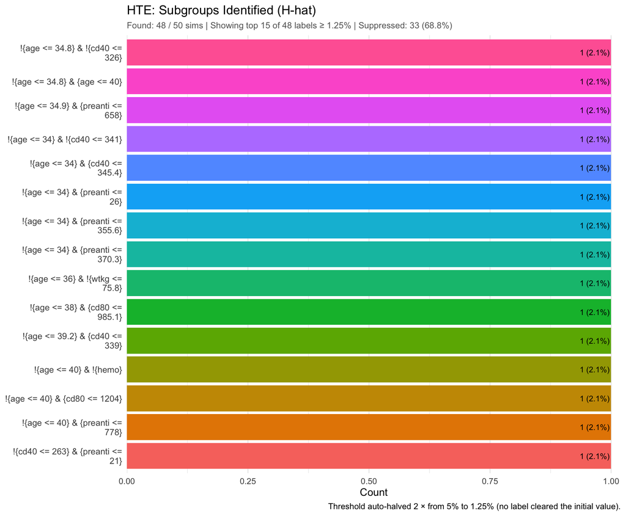

```r
print(plot_sgdist_alt)
```

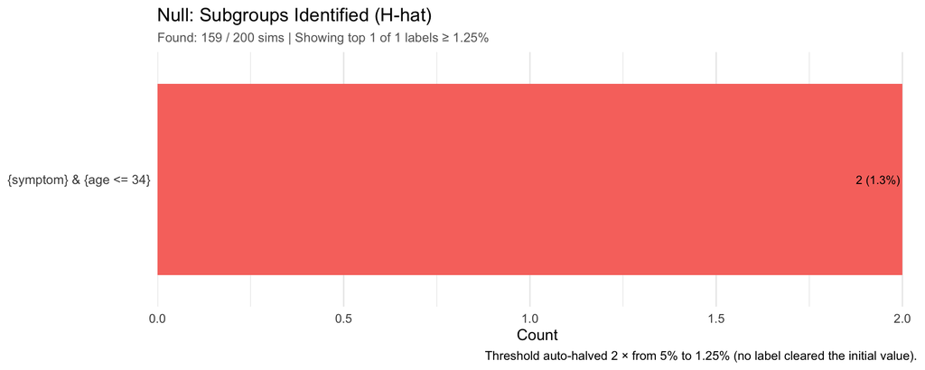

```r
print(plot_sgdist_null)
```

## 7.6 Distribution of HR Estimates

Three-panel violin showing the distribution of HR estimates on the benefit scale across simulations: ITT, the identified $\hat H$, and its complement $\hat H^c$. Under H1 the dotted green line overlays the DGM-implied true HR$(Q)$ on the benefit scale ($1 /$ DGM’s `harm_subgroup` HR).

**H1 HR-distribution violin (click to expand)**

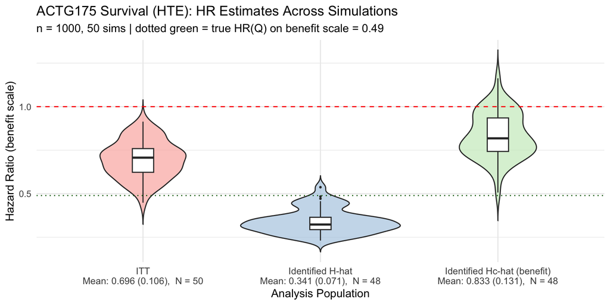

```r
hr_Q_true <- 1 / dgm_calibrated$hazard_ratios$harm_subgroup

plot_effect_distribution(
  results           = results_alt,
  analysis_method   = "FS",
  effect_measure    = "HR",
  subgroup_notation = sg_notation,
  reference_effect  = hr_Q_true,
  title             = "ACTG175 Survival (HTE): HR Estimates Across Simulations",
  subtitle          = sprintf(
    "n = %d, %d sims | dotted green = true HR(Q) on benefit scale = %.2f",
    sim_n_sample, nsims_alt, hr_Q_true)
)
```

**H0 HR-distribution violin (click to expand)**

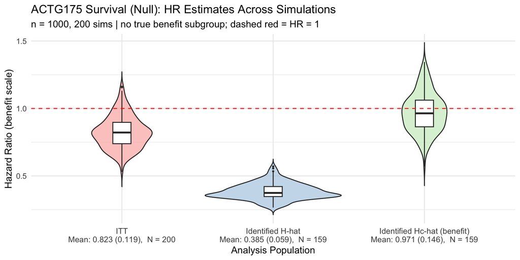

```r
plot_effect_distribution(
  results           = results_null,
  analysis_method   = "FS",
  effect_measure    = "HR",
  subgroup_notation = sg_notation,
  title             = "ACTG175 Survival (Null): HR Estimates Across Simulations",
  subtitle          = sprintf(
    "n = %d, %d sims | no true benefit subgroup; dashed red = HR = 1",
    sim_n_sample, nsims_null)
)
```

# 8 Theoretical Detection Probability

The detection probability is the theoretical power of ForestSearch’s bootstrap consistency rule to flag a subgroup with a given HR, given the expected subgroup size and censoring proportion. This curve provides a reference for interpreting the empirical detection rate observed in the simulation.

The `method = "cubature"` argument uses numerical integration (via the `cubature` package) to compute the joint probability that the subgroup HR exceeds `hr.threshold` (c1) and that the proportion of bootstrap replicates exceeding `hr.consistency` (c2) is at least `pconsistency.threshold`. An alternative `method = "normal"` uses a normal approximation.

```r
n_sg_expected <- sim_config$n_sample *
  mean(dgm_calibrated$df_super$flag_harm)
prop_cens <- mean(results_alt$p.cens)

cat("Expected subgroup size:", round(n_sg_expected), "\n")
```

```
#> Expected subgroup size: 345
```

```r
cat("Censoring proportion:",   round(prop_cens, 3), "\n")
```

```
#> Censoring proportion: 0.792
```

```r
cat("True HR(H):",             round(dgm_calibrated$hazard_ratios$harm_subgroup, 3), "\n")
```

```
#> True HR(H): 2.043
```

```r
prob_detect <- compute_detection_probability(
  theta          = dgm_calibrated$hazard_ratios$harm_subgroup,
  n_sg           = round(n_sg_expected),
  prop_cens      = prop_cens,
  hr_threshold   = fs_params$hr.threshold,
  hr_consistency = fs_params$hr.consistency,
  method         = "cubature"
)

cat("\nTheoretical P(detect):", round(prob_detect, 3), "\n")
```

```
#>
#> Theoretical P(detect): 0.769
```

```r
cat("Empirical FS:",
    round(mean(results_alt[
      results_alt$analysis == "FS", "any.H"
    ]), 3), "\n")
```

```
#> Empirical FS: 0.96
```

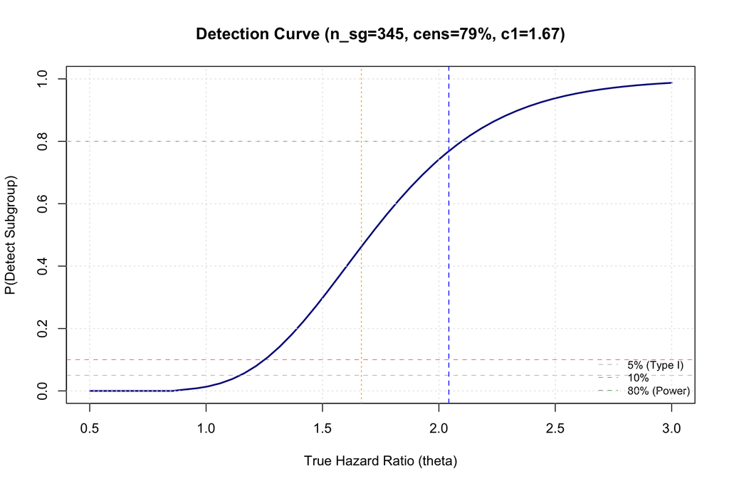

```r
# Generate curve
detection_curve <- generate_detection_curve(
  theta_range       = det_theta_range,
  n_points          = det_n_points,
  n_sg              = round(n_sg_expected),
  prop_cens         = prop_cens,
  hr_threshold      = fs_params$hr.threshold,
  hr_consistency    = fs_params$hr.consistency,
  include_reference = TRUE,
  verbose           = FALSE
)

plot_detection_curve(
  detection_curve,
  add_reference_lines = TRUE,
  add_threshold_line  = TRUE,
  title = sprintf(
    "Detection Curve (n_sg=%d, cens=%.0f%%, c1=%.2f)",
    round(n_sg_expected), 100 * prop_cens,
    fs_params$hr.threshold
  )
)

abline(v = dgm_calibrated$hazard_ratios$harm_subgroup, lty = 2, col = "blue")
```

# 9 Timing Summary

```r
timings$total <- (proc.time() - t_vignette_start)["elapsed"]

timing_df <- data.frame(
  Stage = c(
    "DGM creation (H1)",
    "k_inter calibration",
    "DGM calibrated",
    "DGM creation (H0)",
    "Single-trial ForestSearch",
    "Simulations H1",
    "Simulations H0",
    "Summarize H1",
    "Summarize H0",
    "Total"
  ),
  Seconds = c(
    timings$dgm_alt,
    timings$calibrate,
    timings$dgm_calibrated,
    timings$dgm_null,
    timings$single_fs,
    timings$sims_alt,
    timings$sims_null,
    timings$summarize_alt,
    timings$summarize_null,
    timings$total
  ),
  stringsAsFactors = FALSE
)
timing_df$Minutes <- timing_df$Seconds / 60
timing_df$Hours   <- timing_df$Seconds / 3600

gt::gt(timing_df) |>
  gt::tab_header(
    title    = "Computational Timing Summary",
    subtitle = sprintf(
      "%d H1 + %d H0 sims | %d workers",
      nsims_alt, nsims_null, n_workers
    )
  ) |>
  gt::fmt_number(columns = Seconds, decimals = 1) |>
  gt::fmt_number(columns = Minutes, decimals = 2) |>
  gt::fmt_number(columns = Hours,   decimals = 3) |>
  gt::cols_label(
    Stage   = "Stage",
    Seconds = "Time (sec)",
    Minutes = "Time (min)",
    Hours   = "Time (hr)"
  ) |>
  gt::tab_style(
    style = gt::cell_text(weight = "bold"),
    locations = gt::cells_body(rows = Stage == "Total")
  )
```

Computational Timing Summary

50 H1 + 200 H0 sims | 12 workers

| Stage | Time (sec) | Time (min) | Time (hr) |
| --- | --- | --- | --- |
| DGM creation (H1) | 0.1 | 0.00 | 0.000 |
| k_inter calibration | 0.7 | 0.01 | 0.000 |
| DGM calibrated | 0.0 | 0.00 | 0.000 |
| DGM creation (H0) | 0.0 | 0.00 | 0.000 |
| Single-trial ForestSearch | 1.2 | 0.02 | 0.000 |
| Simulations H1 | 38.2 | 0.64 | 0.011 |
| Simulations H0 | 145.5 | 2.42 | 0.040 |
| Summarize H1 | 0.1 | 0.00 | 0.000 |
| Summarize H0 | 0.1 | 0.00 | 0.000 |
| Total | 216.1 | 3.60 | 0.060 |

### 9.0.1 Projection for Production Runs

```r
# Per-replicate cost by stage
time_per_alt  <- timings$sims_alt / nsims_alt
time_per_null <- timings$sims_null / nsims_null

proj_alt   <- time_per_alt * prod_alt
proj_null  <- time_per_null * prod_null
proj_other <- timings$total - timings$sims_alt - timings$sims_null
proj_total <- proj_alt + proj_null + proj_other

proj_df <- data.frame(
  Component = c("H1 simulations", "H0 simulations", "Other (DGM, calibration, summaries)",
                "Total"),
  Count     = c(
    sprintf("%d replicates", prod_alt),
    sprintf("%d replicates", prod_null),
    "---",
    sprintf("%d + %d", prod_alt, prod_null)
  ),
  `Per replicate` = c(
    sprintf("%.1f sec", time_per_alt),
    sprintf("%.1f sec", time_per_null),
    "---",
    "---"
  ),
  Projected = c(
    sprintf("%.1f min", proj_alt / 60),
    sprintf("%.1f min", proj_null / 60),
    sprintf("%.1f min", proj_other / 60),
    sprintf("%.1f min (%.1f hours)", proj_total / 60, proj_total / 3600)
  ),
  check.names = FALSE,
  stringsAsFactors = FALSE
)

gt::gt(proj_df) |>
  gt::tab_header(
    title = sprintf("Projected Time: %d alt + %d null", prod_alt, prod_null),
    subtitle = sprintf(
      "Based on current run (%d + %d on %d workers)",
      nsims_alt, nsims_null, n_workers
    )
  ) |>
  gt::tab_style(
    style = gt::cell_text(weight = "bold"),
    locations = gt::cells_body(rows = Component == "Total")
  )
```

Projected Time: 10000 alt + 20000 null

Based on current run (50 + 200 on 12 workers)

| Component | Count | Per replicate | Projected |
| --- | --- | --- | --- |
| H1 simulations | 10000 replicates | 0.8 sec | 127.4 min |
| H0 simulations | 20000 replicates | 0.7 sec | 242.4 min |
| Other (DGM, calibration, summaries) | --- | --- | 0.5 min |
| Total | 10000 + 20000 | --- | 370.4 min (6.2 hours) |

# 10 Discussion

## 10.1 Key Differences from the GBSG Simulation

The ACTG175 dataset introduces several features that test ForestSearch under different conditions than the GBSG template:

1. **Larger sample size** ($N \approx 1{,}000$ vs $686$): more candidate subgroups survive the `n.min` filter, potentially increasing $L_{\text{eff}}$ and the procedure-level FPR.
2. **More confounders** ($12$ vs $7$): the combinatorial search space is larger, testing GRF and LASSO screening effectiveness.
3. **Different event rate**: ACTG175 has a lower event rate than GBSG, which reduces $d_{\text{eff}}$ per subgroup and may affect detection power.
4. **Different subgroup structure**: the age $\times$ preanti subgroup is defined by continuous variables discretised at clinically motivated cutpoints, rather than the GBSG’s receptor-status $\times$ menopausal-status interaction.
5. **Time scale**: ACTG175 times have been converted from days to months for AFT model parametrisation but not the HR-scale operating characteristics.

## 10.2 Reloading Saved Results

When `save_results = TRUE`, the simulation bundle is saved as an `.rds` file in the `_data/` directory. To reload for downstream analysis:

```r
bundle <- readRDS("_data/actg175_survival_benefit_simulations_50alts_50nulls.rds")

# Core results (data.tables)
results_alt  <- bundle$results_alt
results_null <- bundle$results_null

# DGM objects (class "aft_dgm_flex")
dgm_cal  <- bundle$dgm_calibrated
dgm_null <- bundle$dgm_null

# True effects
bundle$true_effects$hr_Q     # HR(Q) on switched scale
bundle$true_effects$ahr_Q    # AHR(Q)
bundle$true_effects$k_inter  # calibrated interaction multiplier

# Reproduce tables
format_oc_results(results_alt, subgroup_notation = "benefit", ...)
build_estimation_table(results_alt, dgm = dgm_cal,
                       subgroup_notation = "benefit", ...)
```

## 10.3 Limitations

- The ACTG175 benefit subgroup definition (age $> 34$ AND preanti $\leq 744.5$) is based on the exploratory analysis in León et al. (2024, §4.2). The true treatment effect heterogeneity pattern in ACTG175 is unknown.
- The benefit-search approach (treatment switching) adds a layer of indirection: all DGM, simulation, and ForestSearch operations use the switched treatment indicator, and results must be inverted for interpretation on the original treatment scale.
- `generate_aft_dgm_flex()` requires more analyst judgment than `setup_gbsg_dgm()`. The variable discretisation, subgroup definition, and censoring calibration must all be specified manually.
- The simulation count (50 sims) is for demonstration. Production studies should use $\geq 500$ simulations for stable operating characteristics (Monte Carlo SE for a 50% rate $\approx 2.2\%$ at 500 sims).
- The adjusted Cox formula (`cox_formula_adj`) includes only 3 of 12 confounders. This is a deliberate choice for parsimony, but users should select confounders appropriate for their study design.
- `calibrate_k_inter()` does not yet support non-GBSG datasets; the manual grid search in Section 4.3 is the current workaround.

# 12 References

- Leon, L.F., Jemielita, T., Guo, Z., Marceau West, R., Anderson, K.M. (2024). Exploratory subgroup identification in the heterogeneous Cox model. *Statistics in Medicine*, 43, 4253–4275.
- Hammer, S.M., Katzenstein, D.A., Hughes, M.D., et al. (1996). A trial comparing nucleoside monotherapy with combination therapy in HIV-infected adults with CD4 cell counts from 200 to 500 per cubic millimeter. *NEJM*, 335, 1081–1090.